title: “YouTube Views Analysis” author: “Matt Eisenbrei” date: “9/6/2019” output: html_document

# Data set: Trending YouTube Video Statistics

# Data source: https://www.kaggle.com/datasnaek/youtube-new

# **Primary:** Predict youtube video views based on key variables. Use the resulting model to predict hypothetical views for a video.

# **Secondary 1:** Carefully assess the model’s variables, dropping less useful variables and adding new variables which can help to tell a good story.

# **Secondary 2:** Identify a “best” model using stepwise selection and cross-validation.

# **PART 1: INITIAL DATA ASSESSMENT**

## Import the US data set.

```r
setwd("E:/Matt/UCLA Data Science Intensive/Capstone")
us.data=read.csv("USVideos.csv")
```

## Review the structure to check for missing or NA values.

```r
str(us.data)
```

```
## 'data.frame':    40949 obs. of  16 variables:
##  $ video_id              : Factor w/ 6282 levels "-0CMnp02rNY",..: 378 319 711 4337 1755 2418 454 3797 3063 5155 ...
##  $ trending_date         : Factor w/ 205 levels "17.01.12","17.02.12",..: 14 14 14 14 14 14 14 14 14 14 ...
##  $ title                 : Factor w/ 6455 levels "'Avengers: Infinity War' Cast Tours Los Angeles w/ James Corden",..: 6046 5527 4441 4068 2640 161 4625 256 5352 6305 ...
##  $ channel_title         : Factor w/ 2207 levels "12 News","1MILLION Dance Studio",..: 332 1109 1651 768 1424 890 1681 464 4 2126 ...
##  $ category_id           : int  22 24 23 24 24 28 24 28 1 25 ...
##  $ publish_time          : Factor w/ 6269 levels "2006-07-23T08:24:11.000Z",..: 318 287 271 291 269 323 256 274 297 295 ...
##  $ tags                  : Factor w/ 6055 levels "#guitar #musiciseverywhere #jammin #meme #funny #deeppurple #pinkfloyd",..: 4673 3071 4300 4442 4521 2487 4808 64 5563 5782 ...
##  $ views                 : int  748374 2418783 3191434 343168 2095731 119180 2103417 817732 826059 256426 ...
##  $ likes                 : int  57527 97185 146033 10172 132235 9763 15993 23663 3543 12654 ...
##  $ dislikes              : int  2966 6146 5339 666 1989 511 2445 778 119 1363 ...
##  $ comment_count         : int  15954 12703 8181 2146 17518 1434 1970 3432 340 2368 ...
##  $ thumbnail_link        : Factor w/ 6352 levels "https://i.ytimg.com/vi/-_jlqATo9eo/default.jpg",..: 447 388 780 4407 1824 2487 523 3866 3132 5225 ...
##  $ comments_disabled     : logi  FALSE FALSE FALSE FALSE FALSE FALSE ...
##  $ ratings_disabled      : logi  FALSE FALSE FALSE FALSE FALSE FALSE ...
##  $ video_error_or_removed: logi  FALSE FALSE FALSE FALSE FALSE FALSE ...
##  $ description           : Factor w/ 6902 levels "","'A curious cat helps his owner with home improvements.'\\nWe're releasing a NEW BLACK & WHITE episode every wee"| __truncated__,..: 4844 4286 6380 6122 2630 6262 1611 2724 2973 1872 ...
```

```r
summary(us.data)
```

```
##         video_id      trending_date
##  #NAME?     :  397   17.01.12:  200
##  j4KvrAUjn6c:   30   17.02.12:  200
##  8h--kFui1JA:   29   17.03.12:  200
##  iILJvqrAQ_w:   29   17.04.12:  200
##  MAjY8mCTXWk:   29   17.05.12:  200
##  NBSAQenU2Bk:   29   17.06.12:  200
##  (Other)    :40406   (Other) :39749
##                                                                           title
##  WE MADE OUR MOM CRY...HER DREAM CAME TRUE!                                  :   30
##  Charlie Puth - BOY [Official Audio]                                         :   29
##  Mission: Impossible - Fallout (2018) - Official Trailer - Paramount Pictures:   29
##  Rooster Teeth Animated Adventures - Millie So Serious                       :   29
##  Sam Smith - Pray (Official Video) ft. Logic                                 :   29
##  The ULTIMATE $30,000 Gaming PC Setup                                        :   29
##  (Other)                                                                     :40774
##                                 channel_title    category_id
##  ESPN                                  :  203   Min.   : 1.00
##  The Tonight Show Starring Jimmy Fallon:  197   1st Qu.:17.00
##  Netflix                               :  193   Median :24.00
##  TheEllenShow                          :  193   Mean   :19.97
##  Vox                                   :  193   3rd Qu.:25.00
##  The Late Show with Stephen Colbert    :  187   Max.   :43.00
##  (Other)                               :39783
##                    publish_time
##  2018-05-18T14:00:04.000Z:   50
##  2018-05-06T13:00:05.000Z:   32
##  2018-05-13T18:03:56.000Z:   30
##  2018-05-09T17:00:00.000Z:   29
##  2018-05-11T04:00:34.000Z:   29
##  2018-05-13T19:00:25.000Z:   29
##  (Other)                 :40750
##                                                                                                                                                                                                                                                                                                          …
##  [none]                                                                                                                                                                                                                                                                                                  …
##  ABC|"americanidol"|"idol"|"american idol"|"ryan"|"seacrest"|"ryan seacrest"|"katy"|"perry"|"katy perry"|"luke"|"bryan"|"luke bryan"|"lionel"|"richie"|"lionel richie"|"season 16"|"american idol XVI"|"television"|"ad"|"spring"|"2018"|"music"|"reality"|"competition"|"song"|"sing"|"audition"|"auditi…
##  Jacksfilms|"Jack Douglass"|"YGS"|"YGS 100"|"YGS 50"|"The Best of Your Grammar Sucks"|"Your Grammar Sucks"|"YIAY"|"Yesterday I Asked You"|"Fidget Spinners"|"Emoji Movie"|"Kermit Sings"|"JackAsk"|"Jack Ask"|"Dubstep Solves Everything"|"Frozen 2"|"iPhone Parody"|"Apple Parody"                      …
##  James Corden|"The Late Late Show"|"Colbert"|"late night"|"late night show"|"Stephen Colbert"|"Comedy"|"monologue"|"comedian"|"impressions"|"celebrities"|"carpool"|"karaoke"|"CBS"|"Late Late Show"|"Corden"|"joke"|"jokes"|"funny"|"funny video"|"funny videos"|"humor"|"celebrity"|"celeb"|"hollywood"…
##  The Late Show|"Stephen Colbert"|"Colbert"|"Late Show"|"celebrities"|"late night"|"talk show"|"skits"|"bit"|"monologue"|"The Late Late Show"|"Late Late Show"|"letterman"|"david letterman"|"comedian"|"impressions"|"CBS"|"joke"|"jokes"|"funny"|"funny video"|"funny videos"|"humor"|"celebrity"|"celeb…
##  BIGHIT|"ë¹…íž\210íŠ¸"|"ë°©íƒ„ì†Œë…„ë‹¨"|"BTS"|"BANGTAN"|"ë°©íƒ„"                                                                                                                                                                                                                                        …
##  (Other)                                                                                                                                                                                                                                                                                                 …
```

[output cut: 17 more lines]

```
##  Mode :logical    Mode :logical
##  FALSE:40780      FALSE:40926
##  TRUE :169        TRUE :23
##
##
##
##
##                                                                                                                                                                                                                                                                                                          …
##                                                                                                                                                                                                                                                                                                          …
##  â–º Listen LIVE: http://power1051fm.com/\\nâ–º Facebook: https://www.facebook.com/Power1051NY/\\nâ–º Twitter: https://twitter.com/power1051/\\nâ–º Instagram: https://www.instagram.com/power1051/                                                                                                      …
##  Jukin Media Verified (Original) * For licensing / permission to use: Contact - licensing(at)jukinmediadotcom\\nSubmit your videos here: http://bit.ly/2iFnUya                                                                                                                                           …
##  My Twitter: https://twitter.com/prozdkp\\nMy Let's Play channel, Press Buttons n Talk:\\nhttps://www.youtube.com/channel/UCSHsNH4FZXFeSQMJ56AdrBA\\nMy Merch/T-Shirt Store: http://www.theyetee.com/prozd\\nMy Tumblr: http://prozdvoices.tumblr.com/\\nMy Twitch: https://www.twitch.tv/prozd\\nMy Inst…
##  BEST MOM EVER! WANT TO SEE US IN NYC & NJ?!BUY TIX HERE! âž¨ http://bit.ly/DobreTour WE POST TUESDAY,THURSDAY, & SUNDAY!TURN OUR POST NOTIFICATIONS ON FOR A SHOUTOUT!SUBSCRIBE TO THE DOBRE VLOG CHANNEL! https://www.youtube.com/channel/UCC3OGYxHwV8pB5yLobw9KdASUBSCRIBE TO THE LUCAS AND MARCUS CHA…
##  Fortnite, PUBG, Far Cry 5? Which game would you play on this gaming PC setup?Visit SteelSeries.com and use discount code â\200œUnbox15â\200\235(letters in discount code ARE case sensitive) to get an Unbox 24hr exclusive of 15% off Arctis Pro + GameDAC: http://steelseries.com/arctisproThe Chair -…
##  (Other)                                                                                                                                                                                                                                                                                                 …
```

```r
sapply(us.data,function(x)sum(is.na(x)))
```

```
##               video_id          trending_date                  title
##                      0                      0                      0
##          channel_title            category_id           publish_time
##                      0                      0                      0
##                   tags                  views                  likes
##                      0                      0                      0
##               dislikes          comment_count         thumbnail_link
##                      0                      0                      0
##      comments_disabled       ratings_disabled video_error_or_removed
##                      0                      0                      0
##            description
##                      0
```

## Fortunately, none were found in the fields we plan to keep. We can keep most of the 40K+ observations.

## Overall, we have a fairly “skinny” data set (many observations, comparatively fewer variables) so a linear model may be a good fit.

# **PART 1A: Add explanatory variables to conduct more insightful analyses.**

## First we load the package required to read JSON files so we can label content by genre for analysis.

```r
library("rjson")
US.category.names=fromJSON(file="US_category_id.json")
US_categories=as.data.frame(US.category.names)
str(US_categories)
```

```
## 'data.frame':    1 obs. of  194 variables:
##  $ kind                       : Factor w/ 1 level "youtube#videoCategoryListResponse": 1
##  $ etag                       : Factor w/ 1 level "\"m2yskBQFythfE4irbTIeOgYYfBU/S730Ilt-Fi-emsQJvJAAShlR6hM\"": 1
##  $ items.kind                 : Factor w/ 1 level "youtube#videoCategory": 1
##  $ items.etag                 : Factor w/ 1 level "\"m2yskBQFythfE4irbTIeOgYYfBU/Xy1mB4_yLrHy_BmKmPBggty2mZQ\"": 1
##  $ items.id                   : Factor w/ 1 level "1": 1
##  $ items.snippet.channelId    : Factor w/ 1 level "UCBR8-60-B28hp2BmDPdntcQ": 1
##  $ items.snippet.title        : Factor w/ 1 level "Film & Animation": 1
##  $ items.snippet.assignable   : logi TRUE
##  $ items.kind.1               : Factor w/ 1 level "youtube#videoCategory": 1
##  $ items.etag.1               : Factor w/ 1 level "\"m2yskBQFythfE4irbTIeOgYYfBU/UZ1oLIIz2dxIhO45ZTFR3a3NyTA\"": 1
##  $ items.id.1                 : Factor w/ 1 level "2": 1
##  $ items.snippet.channelId.1  : Factor w/ 1 level "UCBR8-60-B28hp2BmDPdntcQ": 1
##  $ items.snippet.title.1      : Factor w/ 1 level "Autos & Vehicles": 1
##  $ items.snippet.assignable.1 : logi TRUE
```

[output cut: 86 more lines]

## Then we review the data from the .json file and extract the category_id and genre data.

```r
col.list1=US_categories[,grep("items.snippet.title",colnames(US_categories))]
col.list1
```

```
##   items.snippet.title items.snippet.title.1 items.snippet.title.2
## 1    Film & Animation      Autos & Vehicles                 Music
##   items.snippet.title.3 items.snippet.title.4 items.snippet.title.5
## 1        Pets & Animals                Sports          Short Movies
##   items.snippet.title.6 items.snippet.title.7 items.snippet.title.8
## 1       Travel & Events                Gaming         Videoblogging
##   items.snippet.title.9 items.snippet.title.10 items.snippet.title.11
## 1        People & Blogs                 Comedy          Entertainment
##   items.snippet.title.12 items.snippet.title.13 items.snippet.title.14
## 1        News & Politics          Howto & Style              Education
##   items.snippet.title.15 items.snippet.title.16 items.snippet.title.17
## 1   Science & Technology  Nonprofits & Activism                 Movies
##   items.snippet.title.18 items.snippet.title.19 items.snippet.title.20
## 1        Anime/Animation       Action/Adventure               Classics
##   items.snippet.title.21 items.snippet.title.22 items.snippet.title.23
## 1                 Comedy            Documentary                  Drama
##   items.snippet.title.24 items.snippet.title.25 items.snippet.title.26
## 1                 Family                Foreign                 Horror
##   items.snippet.title.27 items.snippet.title.28 items.snippet.title.29
## 1         Sci-Fi/Fantasy               Thriller                 Shorts
##   items.snippet.title.30 items.snippet.title.31
## 1                  Shows               Trailers
```

```r
col.list2=US_categories[,grep("items.id",colnames(US_categories))]
col.list2
```

```
##   items.id items.id.1 items.id.2 items.id.3 items.id.4 items.id.5
## 1        1          2         10         15         17         18
##   items.id.6 items.id.7 items.id.8 items.id.9 items.id.10 items.id.11
## 1         19         20         21         22          23          24
##   items.id.12 items.id.13 items.id.14 items.id.15 items.id.16 items.id.17
## 1          25          26          27          28          29          30
##   items.id.18 items.id.19 items.id.20 items.id.21 items.id.22 items.id.23
## 1          31          32          33          34          35          36
##   items.id.24 items.id.25 items.id.26 items.id.27 items.id.28 items.id.29
## 1          37          38          39          40          41          42
##   items.id.30 items.id.31
## 1          43          44
```

## Next, we export the .json file data frames, combine them in Excel as “key.csv”, then import “key.csv” and make it a data frame.

```r
write.csv(col.list1,"E:/Matt/UCLA Data Science Intensive/Capstone/list1.csv", row.names = FALSE)
write.csv(col.list2,"E:/Matt/UCLA Data Science Intensive/Capstone/list2.csv", row.names = FALSE)

categories.us=read.csv(file="E:/Matt/UCLA Data Science Intensive/Capstone/key.csv",header=T, sep=",")
cat.us=as.data.frame(categories.us)
summary(cat.us)
```

```
##               genre     category_id
##  Comedy          : 2   Min.   : 1.00
##  Action/Adventure: 1   1st Qu.:20.75
##  Anime/Animation : 1   Median :28.50
##  Autos & Vehicles: 1   Mean   :27.56
##  Classics        : 1   3rd Qu.:36.25
##  Documentary     : 1   Max.   :44.00
##  (Other)         :25
```

## Following those steps, we add the genre data to the qualitative data set.

```r
us.data=merge(us.data,cat.us,by="category_id")
```

## Now we will look at time series and text variables.

## First we add new day of week variables for exploration.

## We look at trending_data and add a new variable to note day of the week for trending, “trending_weekday”.

```r
us.data$trending_date=as.Date(us.data$trending_date,"%Y.%d.%m")
us.data$trending_weekday=weekdays(us.data$trending_date)
us.data$trending_weekday=as.factor(us.data$trending_weekday)
```

## Then we break the “publish_time” variable into two new variables, “publish_date” and “publish_date_weekly”.

```r
us.data$publish_date=substr(us.data$publish_time,1,10)
us.data$publish_date=as.Date(us.data$publish_date,"%Y-%m-%d")
us.data$publish_date_weekday=weekdays(us.data$publish_date)
us.data$publish_date_weekday=as.factor(us.data$publish_date_weekday)
```

## Next we look at sentiment analysis to assess whether any text sentiment can help to explain the dependent variable (views).

## First we load the key libraries.

```r
library(sentimentr)
library(stringr)
library(tidyverse)
library(tidytext)
library(tm)
library(gmodels)
```

## Then we change some of the text fields to character format before creating new variables.

## We start with video title sentiment.

```r
us.data$title=as.character(us.data$title)
title.sent=get_sentences(us.data$title)
df1=sentiment_by(title.sent)
us.data$title.sentiment=df1$ave_sentiment
```

## Then we add channel title sentiment.

```r
us.data$channel_title=as.character(us.data$channel_title)
channel_title.sent=get_sentences(us.data$channel_title)
df2=sentiment_by(channel_title.sent)
us.data$channel_title.sentiment=df2$ave_sentiment
```

## Next, we include tags.

```r
us.data$tags=as.character(us.data$tags)
tags.sent=get_sentences(us.data$tags)
df3=sentiment_by(tags.sent)
us.data$tags.sentiment=df3$ave_sentiment
```

## Finally, we add description.

```r
us.data$description=as.character(us.data$description)
description.sent=get_sentences(us.data$description)
df4=sentiment_by(description.sent)
us.data$description.sentiment=df4$ave_sentiment
str(us.data)
```

```
## 'data.frame':    40949 obs. of  24 variables:
##  $ category_id            : int  1 1 1 1 1 1 1 1 1 1 ...
##  $ video_id               : Factor w/ 6282 levels "-0CMnp02rNY",..: 2373 3438 4798 5527 804 5445 1700 2801 6143 3438 ...
##  $ trending_date          : Date, format: "0018-02-26" "0018-03-12" ...
##  $ title                  : chr  "Honest Trailers - Justice League" "Everything Wrong With Birdman In 13 Minutes Or Less" "BEIRUT | Official Trailer" "Apple Dessert that looks like a real apple!  No mold challenge" ...
##  $ channel_title          : chr  "Screen Junkies" "CinemaSins" "Bleecker Street" "How To Cook That" ...
##  $ publish_time           : Factor w/ 6269 levels "2006-07-23T08:24:11.000Z",..: 4141 4371 2580 5405 5875 722 3238 1535 1478 4371 ...
##  $ tags                   : chr  "screenjunkies|\"screen junkies\"|\"honest trailers\"|\"honest trailer\"|\"justice league\"|\"dc movies\"|\"wond"| __truncated__ "birdman|\"bird man\"|\"michael keaton\"|\"cinemasins\"|\"cinema sins\"|\"everything wrong with\"|\"eww\"|\"movi"| __truncated__ "bleec…
##  $ views                  : int  2633079 1080795 5186780 259340 12887949 153898 705015 228745 28013 945670 ...
##  $ likes                  : int  69999 23939 510 9059 338755 7551 37505 1848 2374 21927 ...
##  $ dislikes               : int  2377 950 1774 177 6727 1028 1413 41 15 832 ...
##  $ comment_count          : int  10501 2282 665 934 19502 1904 16044 144 102 2131 ...
##  $ thumbnail_link         : Factor w/ 6352 levels "https://i.ytimg.com/vi/-_jlqATo9eo/default.jpg",..: 2442 3507 4868 5597 873 5515 1769 2870 6213 3507 ...
##  $ comments_disabled      : logi  FALSE FALSE FALSE FALSE FALSE FALSE ...
##  $ ratings_disabled       : logi  FALSE FALSE FALSE FALSE FALSE FALSE ...
##  $ video_error_or_removed : logi  FALSE FALSE FALSE FALSE FALSE FALSE ...
##  $ description            : chr  "Somewhere between the awful Suicide Squad and the really good Wonder Woman, there's a movie that is determined "| __truncated__ "Birdman is a pretty great movie, with a lot of unique touches. We love it. But like all movies, it's got sins, "| __truncated__ "Offic…
##  $ genre                  : Factor w/ 31 levels "Action/Adventure",..: 11 11 11 11 11 11 11 11 11 11 ...
##  $ trending_weekday       : Factor w/ 7 levels "Friday","Monday",..: 2 2 7 5 1 5 4 2 5 1 ...
##  $ publish_date           : Date, format: "2018-02-20" "2018-02-27" ...
##  $ publish_date_weekday   : Factor w/ 7 levels "Friday","Monday",..: 6 6 5 1 6 7 3 6 2 6 ...
##  $ title.sentiment        : num  1 -0.265 0 0.337 0.212 ...
##  $ channel_title.sentiment: num  0 0 0 0 0 0 0 0 0 0 ...
##  $ tags.sentiment         : num  1.942 -0.323 0.2 1.134 0.561 ...
##  $ description.sentiment  : num  0.3117 0.2411 -0.0329 0.2703 0.1687 ...
```

## Now we will investigate how many videos had comments disabled. These videos will not be useful for us if comment_count is a variable with high explanatory power.

```r
sum(us.data$comments_disabled==TRUE)
```

```
## [1] 633
```

## Only 633 observations out of ~41K had comments disabled. We will remove these observations.

## We next investigate how many videos were removed due to errors or technical issues.

```r
sum(us.data$video_error_or_removed==TRUE)
```

```
## [1] 23
```

## There were only 23 videos with confirmed technical issues. These observations will also be removed so that we can analyze videos which did not have technical issues which would prevent views.

# **PART 1B: Begin some Exploratory Data Analysis (EDA)**

## How many videos are there by genre?

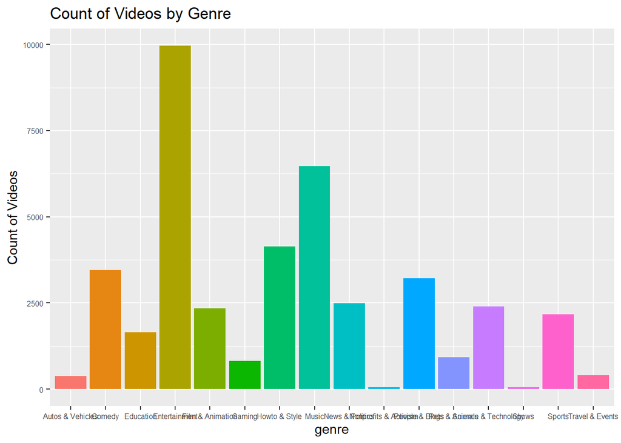

```r
library(ggplot2)
ggplot(us.data) +
  geom_bar(aes(genre,fill=genre)) +
  labs(y="Count of Videos",title ="Count of Videos by Genre")+ theme(axis.text=element_text(size=6),legend.position = "none")
```

## In the US, the Entertainment genre appears to have the highest number of available videos.

## Which genres have the most views on a log scale?

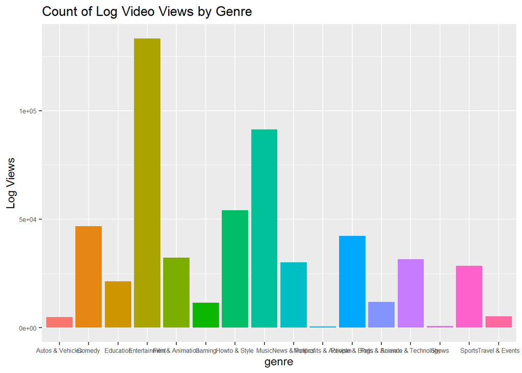

```r
ggplot(us.data,aes(x=genre,y=log(views))) + geom_bar(aes(fill=genre),stat="identity") +
  labs(y="Log Views",title ="Count of Log Video Views by Genre")+ theme(axis.text=element_text(size=6),legend.position = "none")
```

## Again, it’s the Entertainment genre. More videos = more chances for views.

## Which genres have the most likes on a log scale?

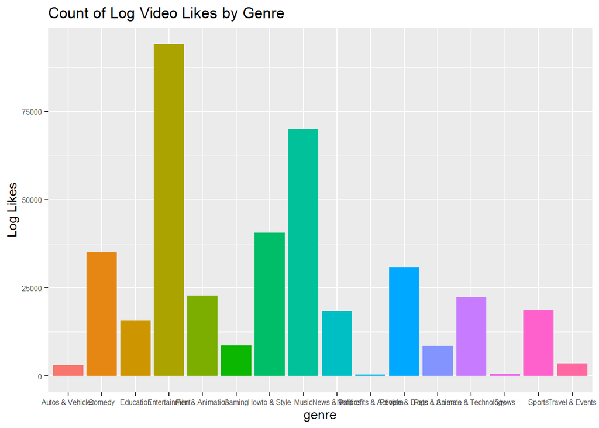

```r
ggplot(us.data,aes(x=genre,y=log(likes))) + geom_bar(aes(fill=genre),stat="identity") +
  labs(y="Log Likes",title ="Count of Log Video Likes by Genre")+ theme(axis.text=element_text(size=6),legend.position = "none")
```

## Variations on a theme. We will need to consider plots that account for the raw number of videos posted by genre, especially for Entertainment.

## Which genres have the most average likes per view?

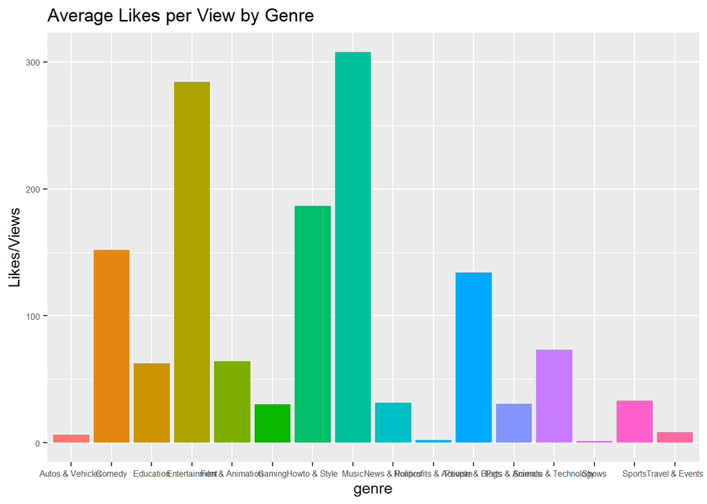

```r
ggplot(us.data,aes(x=genre,y=likes/views)) + geom_bar(aes(fill=genre),stat="identity") +
  labs(y="Likes/Views",title ="Average Likes per View by Genre")+ theme(axis.text=element_text(size=6),legend.position = "none")
```

## This is more interesting, as Music genre videos actually have higher likes per view than Entertainment. After Entertainment, How-to & Style has the next most likes per view.

## Let’s look at dislikes by genre on a log scale.

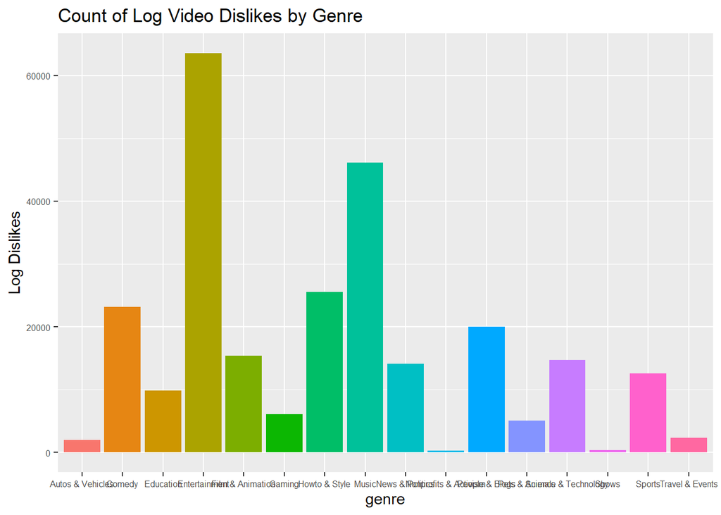

```r
ggplot(us.data,aes(x=genre,y=log(dislikes))) + geom_bar(aes(fill=genre),stat="identity") +
  labs(y="Log Dislikes",title ="Count of Log Video Dislikes by Genre")+ theme(axis.text=element_text(size=6),legend.position = "none")
```

## Entertainment videos have the highest total number of dislikes. Music videos have the second-most total dislikes, followed by How-to & Style. This ties to the number of videos posted in each of these genres.

## Now let’s investigate which genres have the most average dislikes per view.

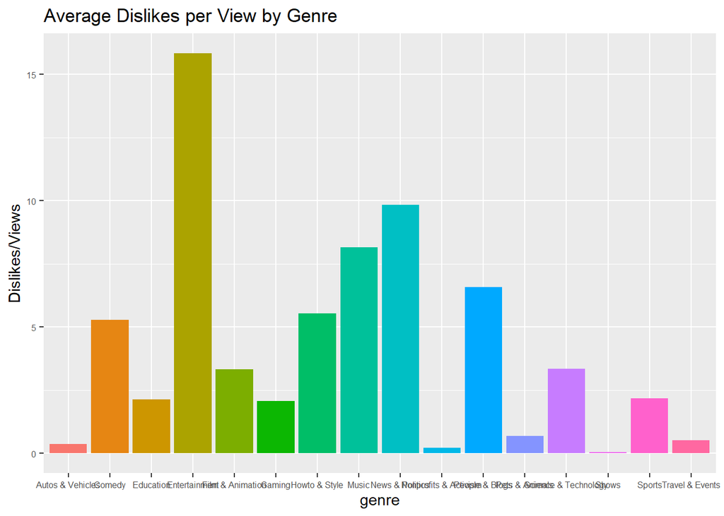

```r
ggplot(us.data,aes(x=genre,y=dislikes/views)) + geom_bar(aes(fill=genre),stat="identity") +
  labs(y="Dislikes/Views",title ="Average Dislikes per View by Genre")+ theme(axis.text=element_text(size=6),legend.position = "none")
```

## Again, it’s the dominant Entertainment genre, but this time followed by News & Politics.

## Comment_count by genre is also interesting:

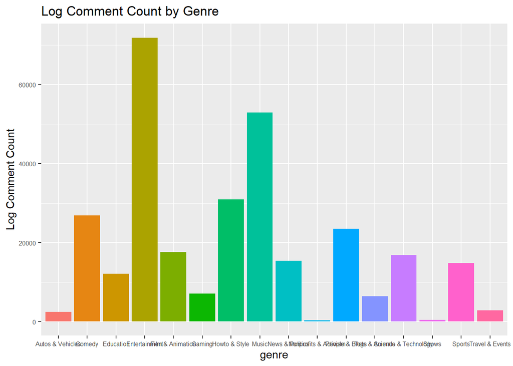

```r
ggplot(us.data,aes(x=genre,y=log(comment_count))) + geom_bar(aes(fill=genre),stat="identity") +
  labs(y="Log Comment Count",title ="Log Comment Count by Genre")+ theme(axis.text=element_text(size=6),legend.position = "none")
```

## Entertainment genre videos generate more total comments than any other genre.

## Let’s evaluate comments per view by genre to see if it’s the same story.

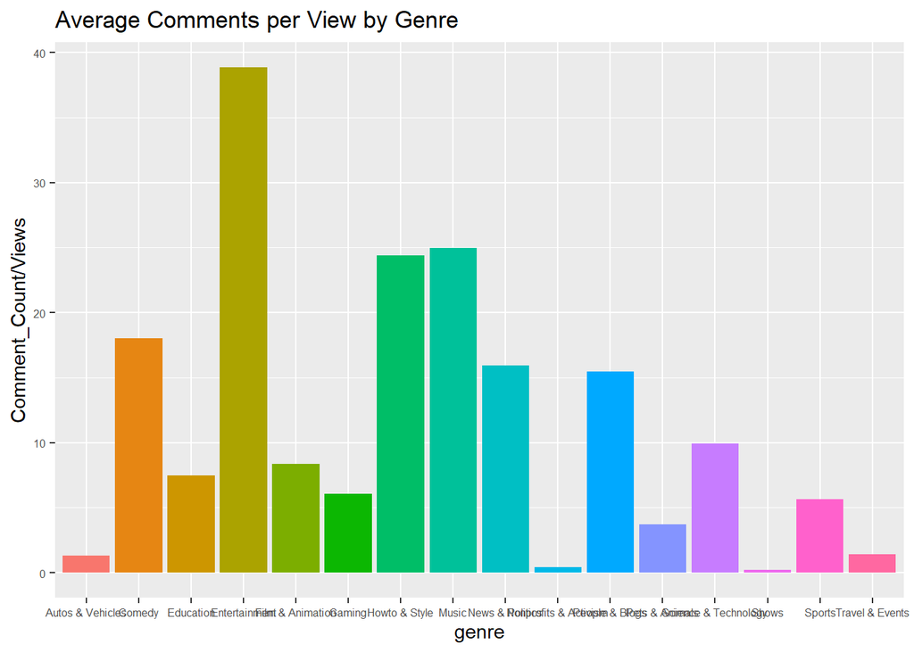

```r
ggplot(us.data,aes(x=genre,y=comment_count/views)) + geom_bar(aes(fill=genre),stat="identity") +
  labs(y="Comment_Count/Views",title ="Average Comments per View by Genre")+ theme(axis.text=element_text(size=6),legend.position = "none")
```

## The most popular genre, Entertainment, also generates the most comments per video view.

## Since there is a sizable difference in the amount of video content available by genre, we should also look at mean values by genre.

## We look at mean values for four of the key variables:

```r
ag.1=aggregate(us.data[,8:11],list(Genre=us.data$genre),mean)
str(ag.1)
```

```
## 'data.frame':    16 obs. of  5 variables:
##  $ Genre        : Factor w/ 31 levels "Action/Adventure",..: 3 5 8 9 11 13 15 17 18 19 ...
##  $ views        : num  1355965 1480308 712941 2067883 3106250 ...
##  $ likes        : num  11056 62582 29745 53243 70788 ...
##  $ dislikes     : num  633 2092 816 4314 2591 ...
##  $ comment_count: num  2043 6522 3286 7383 7628 ...
```

```r
summary(ag.1)
```

```
##               Genre        views             likes
##  Autos & Vehicles: 1   Min.   : 592588   Min.   :  7298
##  Comedy          : 1   1st Qu.: 891300   1st Qu.: 20540
##  Education       : 1   Median :1466468   Median : 42325
##  Entertainment   : 1   Mean   :1855319   Mean   : 64206
##  Film & Animation: 1   3rd Qu.:2206120   3rd Qu.: 64634
##  Gaming          : 1   Max.   :6201003   Max.   :259924
##  (Other)         :10
##     dislikes       comment_count
##  Min.   :  430.0   Min.   : 1669
##  1st Qu.:  839.2   1st Qu.: 2776
##  Median : 1993.0   Median : 5366
##  Mean   : 6247.0   Mean   :11333
##  3rd Qu.: 3458.9   3rd Qu.: 7651
##  Max.   :58076.9   Max.   :84365
##
```

## First we start with mean views. The sheer number of entertainment videos pull the average down. It’s also possible that “Entertainment” is a catch-all term for a broad category.

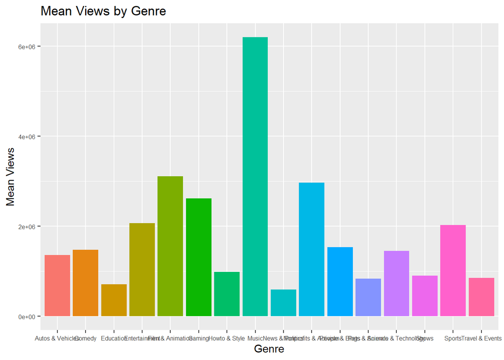

```r
ggplot(ag.1,aes(x=Genre,y=views)) + geom_bar(aes(fill=Genre),stat="identity") +
  labs(y="Mean Views",title ="Mean Views by Genre")+ theme(axis.text=element_text(size=6),legend.position = "none")
```

## Videos in the Music genre have the highest mean views, followed by Film & Animation.

## Next we look at mean likes.

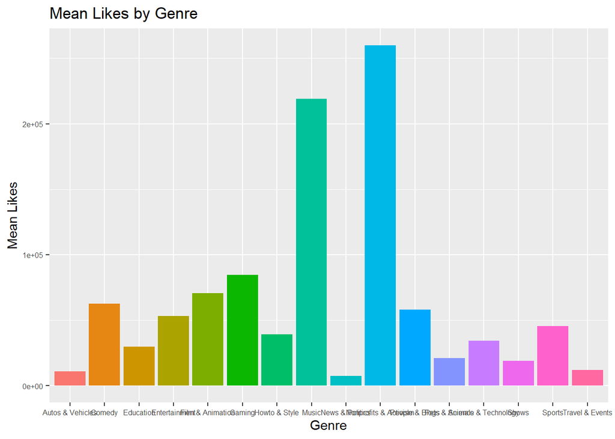

```r
ggplot(ag.1,aes(x=Genre,y=likes)) + geom_bar(aes(fill=Genre),stat="identity") +
  labs(y="Mean Likes",title ="Mean Likes by Genre")+ theme(axis.text=element_text(size=6),legend.position = "none")
```

## Videos in the Nonprofits & Activism genre have the highest mean likes, followed closely by Music.

## Now, mean dislikes.

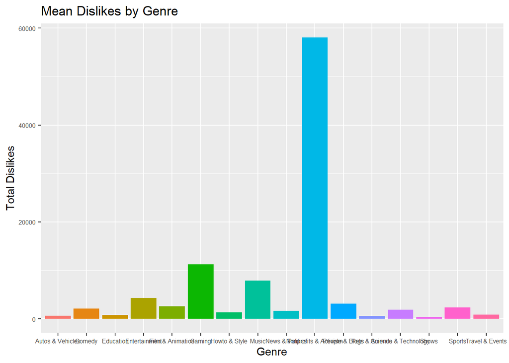

```r
ggplot(ag.1,aes(x=Genre,y=dislikes)) + geom_bar(aes(fill=Genre),stat="identity") +
  labs(y="Total Dislikes",title ="Mean Dislikes by Genre")+ theme(axis.text=element_text(size=6),legend.position = "none")
```

## Videos in the Nonprofits & Activism genre also have the highest mean dislikes. No other genre is close.

## How about mean comment counts per video?

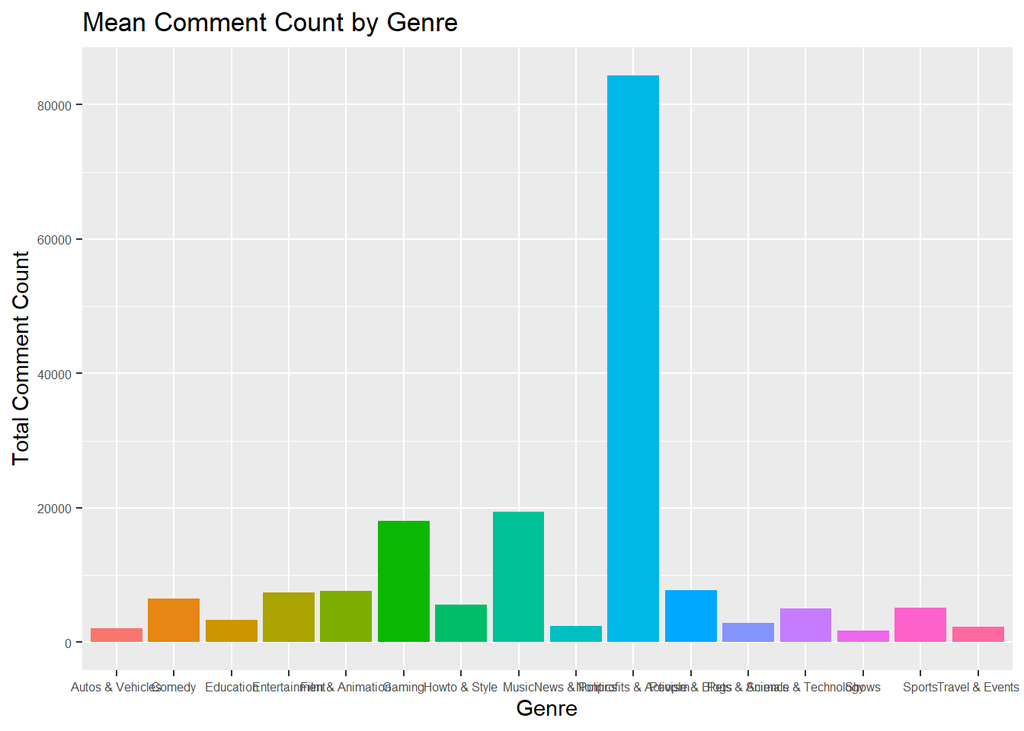

```r
ggplot(ag.1,aes(x=Genre,y=comment_count)) + geom_bar(aes(fill=Genre),stat="identity") +
  labs(y="Total Comment Count",title ="Mean Comment Count by Genre")+ theme(axis.text=element_text(size=6),legend.position = "none")
```

## Videos in the Nonprofits & Activism genre also have the highest mean number of comments, followed by music and gaming.

## It seems logical to assume that viewers are more willing to comment on content that they feel passtionate about.

## Last, we look at the ratio of likes to dislikes by genre:

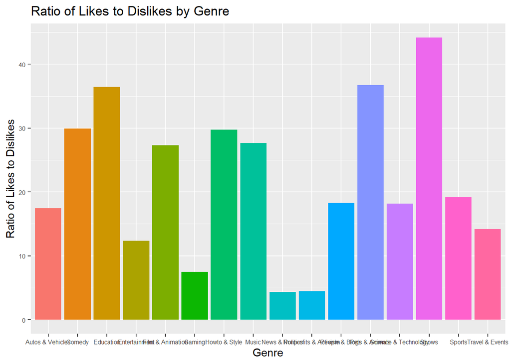

```r
ggplot(ag.1,aes(x=Genre,y=likes/dislikes)) + geom_bar(aes(fill=Genre),stat="identity") +
  labs(y="Ratio of Likes to Dislikes",title ="Ratio of Likes to Dislikes by Genre")+
  theme(axis.text=element_text(size=6),legend.position ="none")
```

## This plot shows that videos in the Shows genre have the highest like ratio, followed by Pets & Animals and Education. It may be difficult to dislike videos about more sentimental or educational topics.

## Now we will check correlations between variables, using log scale where it makes sense.

library(corrplot)

## First we evaluate likes against views and label accordingly.

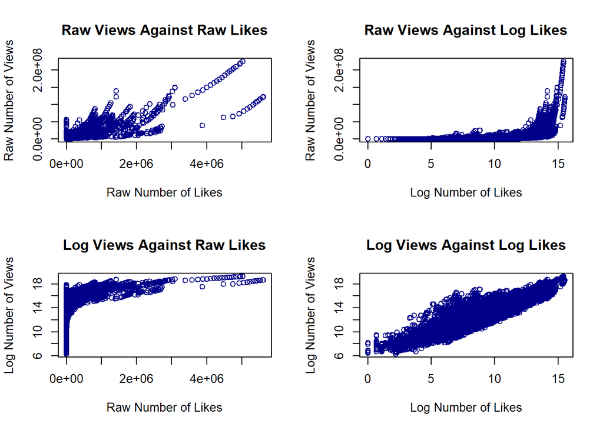

```r
par(mfrow=c(2,2))
plot(us.data$likes,us.data$views,col="dark blue",xlab="Raw Number of Likes",ylab="Raw Number of Views",main="Raw Views Against Raw Likes")
plot(log(us.data$likes),us.data$views,col="dark blue", xlab="Log Number of Likes",ylab="Raw Number of Views",main="Raw Views Against Log Likes")
plot(us.data$likes,log(us.data$views),col="dark blue", xlab="Raw Number of Likes",ylab="Log Number of Views",main="Log Views Against Raw Likes")
plot(log(us.data$likes),log(us.data$views),col="dark blue", xlab="Log Number of Likes",ylab="Log Number of Views",main="Log Views Against Log Likes")
```

```r
par(mfrow=c(1,1))
```

## Next we evaluate dislikes against views and again label accordingly.

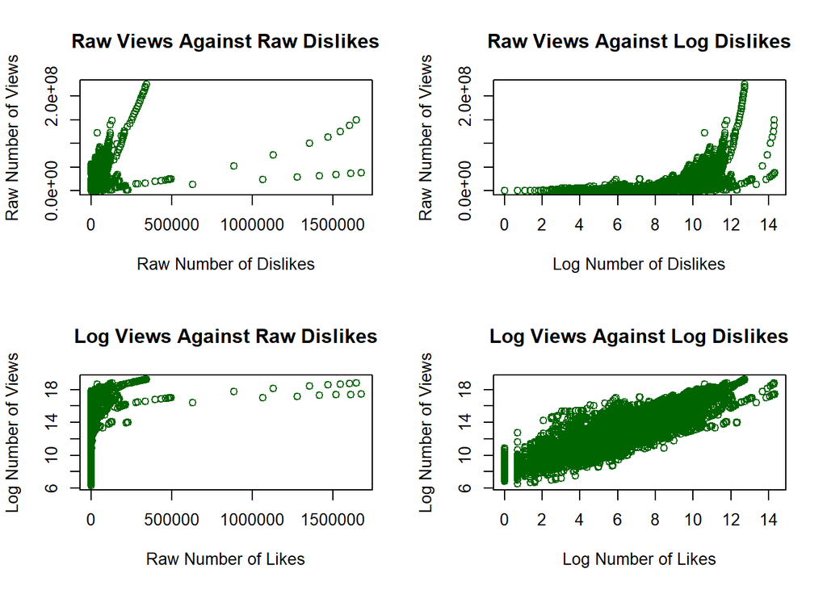

```r
par(mfrow=c(2,2))
plot(us.data$dislikes,us.data$views,col="dark green",xlab="Raw Number of Dislikes",ylab="Raw Number of Views",main="Raw Views Against Raw Dislikes")
plot(log(us.data$dislikes),us.data$views,col="dark green",xlab="Log Number of Dislikes",ylab="Raw Number of Views",main="Raw Views Against Log Dislikes")
plot(us.data$dislikes,log(us.data$views),col="dark green",xlab="Raw Number of Likes",ylab="Log Number of Views",main="Log Views Against Raw Dislikes")
plot(log(us.data$dislikes),log(us.data$views),col="dark green",xlab="Log Number of Likes",ylab="Log Number of Views",main="Log Views Against Log Dislikes")
```

```r
par(mfrow=c(1,1))
```

## Now comment_count against views with correspoding labels.

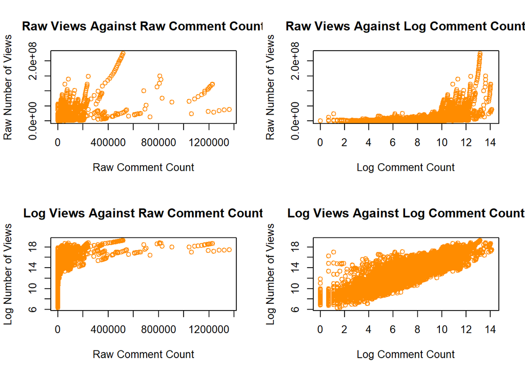

```r
par(mfrow=c(2,2))
plot(us.data$comment_count,us.data$views,col="dark orange",xlab="Raw Comment Count",ylab="Raw Number of Views",main="Raw Views Against Raw Comment Count")
plot(log(us.data$comment_count),us.data$views,col="dark orange",xlab="Log Comment Count",ylab="Raw Number of Views",main="Raw Views Against Log Comment Count")
plot(us.data$comment_count,log(us.data$views),col="dark orange",xlab="Raw Comment Count",ylab="Log Number of Views",main="Log Views Against Raw Comment Count")
plot(log(us.data$comment_count),log(us.data$views),col="dark orange",xlab="Log Comment Count",ylab="Log Number of Views",main="Log Views Against Log Comment Count")
```

```r
par(mfrow=c(1,1))
```

## Note that for all three of the above plots, applying the log of both the x and y variables appears to produce the best result. This represents a % change in the X variable vs. views (Y).

## Now views against trending date:

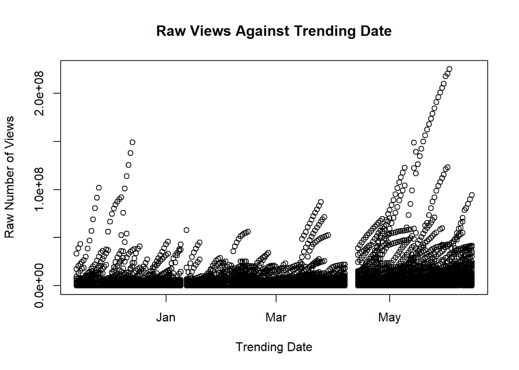

```r
plot(us.data$trending_date,us.data$views, xlab="Trending Date",ylab="Raw Number of Views",main="Raw Views Against Trending Date")
```

## Then views against trending day of the week:

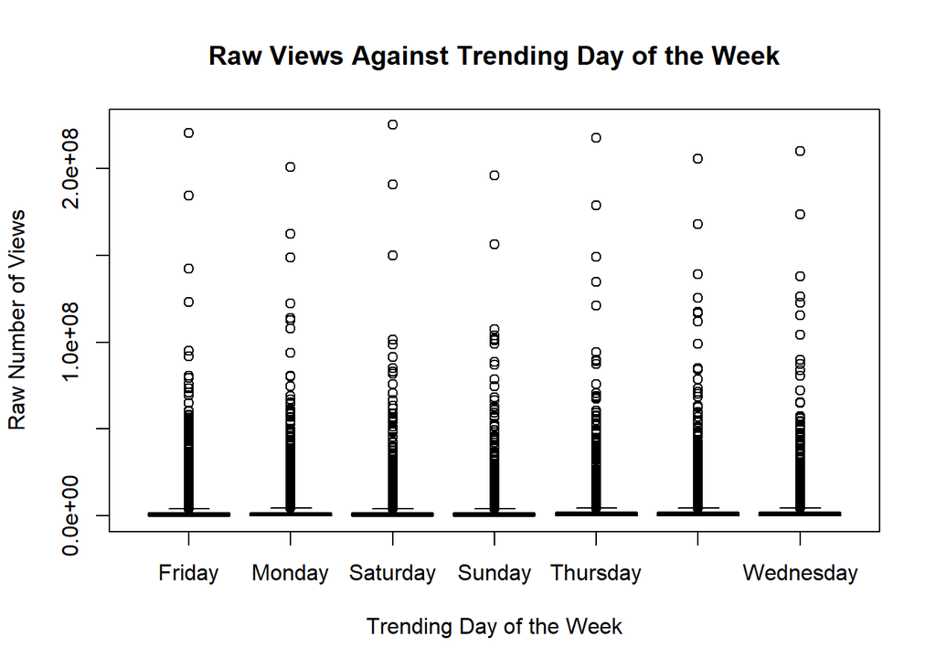

```r
plot(us.data$trending_weekday,(us.data$views), xlab="Trending Day of the Week",ylab="Raw Number of Views",main="Raw Views Against Trending Day of the Week")
```

## Followed by views against publish date and publish day of the week:

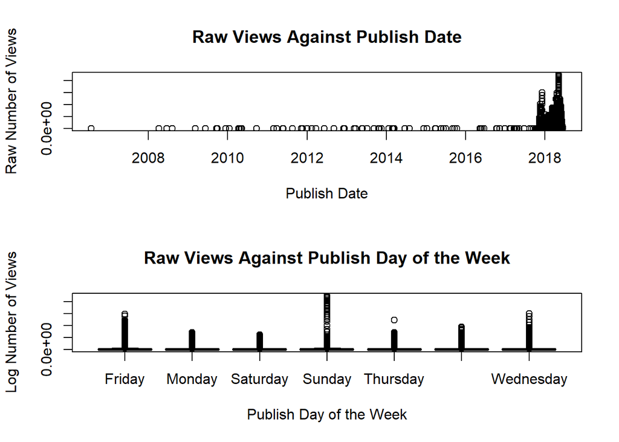

```r
par(mfrow=c(2,1))
plot(us.data$publish_date,us.data$views,xlab="Publish Date",ylab="Raw Number of Views",main="Raw Views Against Publish Date")
plot(us.data$publish_date_weekday,us.data$views,xlab="Publish Day of the Week",ylab="Log Number of Views",main="Raw Views Against Publish Day of the Week")
```

```r
par(mfrow=c(1,1))
```

# **PART 2: QUANTITATIVE DATA ASSESSMENT & REGRESSION**

# **PART 2A: Correlation assessment**

## We now remove variables and observations from the data set where either redundant or of lower explanatory power.

## Remove observations where videos had technical issues or where comments were disabled.

```r
us.data.filter=subset(us.data,comments_disabled==FALSE & video_error_or_removed==FALSE)
str(us.data.filter)
```

```
## 'data.frame':    40293 obs. of  24 variables:
##  $ category_id            : int  1 1 1 1 1 1 1 1 1 1 ...
##  $ video_id               : Factor w/ 6282 levels "-0CMnp02rNY",..: 2373 3438 4798 5527 804 5445 1700 2801 6143 3438 ...
##  $ trending_date          : Date, format: "0018-02-26" "0018-03-12" ...
##  $ title                  : chr  "Honest Trailers - Justice League" "Everything Wrong With Birdman In 13 Minutes Or Less" "BEIRUT | Official Trailer" "Apple Dessert that looks like a real apple!  No mold challenge" ...
##  $ channel_title          : chr  "Screen Junkies" "CinemaSins" "Bleecker Street" "How To Cook That" ...
##  $ publish_time           : Factor w/ 6269 levels "2006-07-23T08:24:11.000Z",..: 4141 4371 2580 5405 5875 722 3238 1535 1478 4371 ...
##  $ tags                   : chr  "screenjunkies|\"screen junkies\"|\"honest trailers\"|\"honest trailer\"|\"justice league\"|\"dc movies\"|\"wond"| __truncated__ "birdman|\"bird man\"|\"michael keaton\"|\"cinemasins\"|\"cinema sins\"|\"everything wrong with\"|\"eww\"|\"movi"| __truncated__ "bleec…
##  $ views                  : int  2633079 1080795 5186780 259340 12887949 153898 705015 228745 28013 945670 ...
##  $ likes                  : int  69999 23939 510 9059 338755 7551 37505 1848 2374 21927 ...
##  $ dislikes               : int  2377 950 1774 177 6727 1028 1413 41 15 832 ...
##  $ comment_count          : int  10501 2282 665 934 19502 1904 16044 144 102 2131 ...
##  $ thumbnail_link         : Factor w/ 6352 levels "https://i.ytimg.com/vi/-_jlqATo9eo/default.jpg",..: 2442 3507 4868 5597 873 5515 1769 2870 6213 3507 ...
##  $ comments_disabled      : logi  FALSE FALSE FALSE FALSE FALSE FALSE ...
##  $ ratings_disabled       : logi  FALSE FALSE FALSE FALSE FALSE FALSE ...
##  $ video_error_or_removed : logi  FALSE FALSE FALSE FALSE FALSE FALSE ...
##  $ description            : chr  "Somewhere between the awful Suicide Squad and the really good Wonder Woman, there's a movie that is determined "| __truncated__ "Birdman is a pretty great movie, with a lot of unique touches. We love it. But like all movies, it's got sins, "| __truncated__ "Offic…
##  $ genre                  : Factor w/ 31 levels "Action/Adventure",..: 11 11 11 11 11 11 11 11 11 11 ...
##  $ trending_weekday       : Factor w/ 7 levels "Friday","Monday",..: 2 2 7 5 1 5 4 2 5 1 ...
##  $ publish_date           : Date, format: "2018-02-20" "2018-02-27" ...
##  $ publish_date_weekday   : Factor w/ 7 levels "Friday","Monday",..: 6 6 5 1 6 7 3 6 2 6 ...
##  $ title.sentiment        : num  1 -0.265 0 0.337 0.212 ...
##  $ channel_title.sentiment: num  0 0 0 0 0 0 0 0 0 0 ...
##  $ tags.sentiment         : num  1.942 -0.323 0.2 1.134 0.561 ...
##  $ description.sentiment  : num  0.3117 0.2411 -0.0329 0.2703 0.1687 ...
```

## Total observations decrease from 40,949 to 40,293.

## We next plan to review correlations but first must remove non-numeric values.

```r
us.data.cor=us.data[,c(1,8:11,21:24)]
str(us.data.cor)
```

```
## 'data.frame':    40949 obs. of  9 variables:
##  $ category_id            : int  1 1 1 1 1 1 1 1 1 1 ...
##  $ views                  : int  2633079 1080795 5186780 259340 12887949 153898 705015 228745 28013 945670 ...
##  $ likes                  : int  69999 23939 510 9059 338755 7551 37505 1848 2374 21927 ...
##  $ dislikes               : int  2377 950 1774 177 6727 1028 1413 41 15 832 ...
##  $ comment_count          : int  10501 2282 665 934 19502 1904 16044 144 102 2131 ...
##  $ title.sentiment        : num  1 -0.265 0 0.337 0.212 ...
##  $ channel_title.sentiment: num  0 0 0 0 0 0 0 0 0 0 ...
##  $ tags.sentiment         : num  1.942 -0.323 0.2 1.134 0.561 ...
##  $ description.sentiment  : num  0.3117 0.2411 -0.0329 0.2703 0.1687 ...
```

## Variable correlation

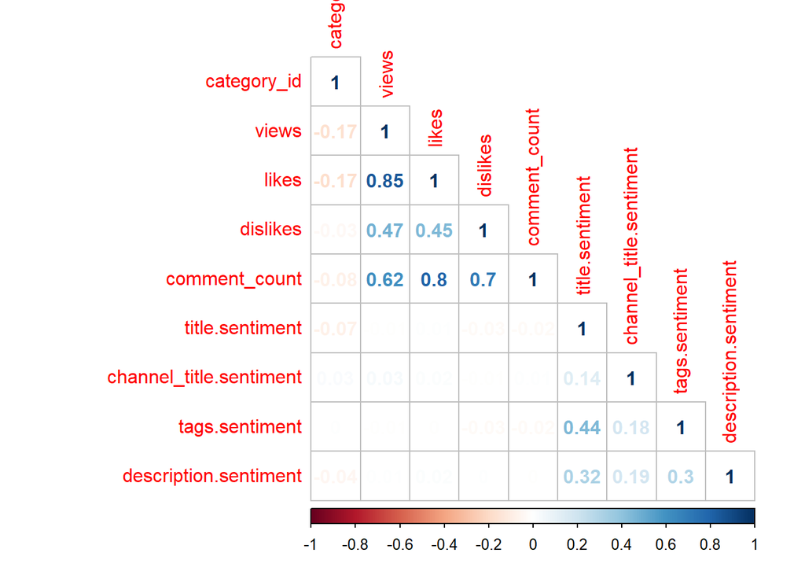

```r
library(corrplot)
us.data.cor=as.matrix(us.data.cor)
cor1=cor(us.data.cor)
corrplot(cor1,type="lower",method="number")
```

## Not surprising, views and likes are highly correlated (0.85). It makes sense to recommend video content with a large numer of likes.

## Likes and comment_count are also highly correlated (0.8), but so are dislikes and comment_count (0.7).

# **PART 2B: Linear Regression**

## We start our regression analysis by analyzing the predictive power of three key variables: likes, dislikes, and comment_count.

```r
model1=lm(views~likes+dislikes+comment_count,data=us.data.filter)
summary(model1)
```

```
##
## Call:
## lm(formula = views ~ likes + dislikes + comment_count, data = us.data.filter)
##
## Residuals:
##       Min        1Q    Median        3Q       Max
## -39610573   -385209   -171146    178202  86661340
##
## Coefficients:
##                 Estimate Std. Error t value Pr(>|t|)
## (Intercept)    2.156e+05  1.774e+04   12.15   <2e-16 ***
## likes          3.556e+01  1.273e-01  279.30   <2e-16 ***
## dislikes       8.311e+01  8.384e-01   99.13   <2e-16 ***
## comment_count -9.765e+01  9.758e-01 -100.07   <2e-16 ***
## ---
## Signif. codes:  0 '***' 0.001 '**' 0.01 '*' 0.05 '.' 0.1 ' ' 1
##
## Residual standard error: 3381000 on 40289 degrees of freedom
## Multiple R-squared:  0.792,  Adjusted R-squared:  0.792
## F-statistic: 5.113e+04 on 3 and 40289 DF,  p-value: < 2.2e-16
```

## Adjusted R2 is .792 with only three variables. Very high.

## Surprisingly, comment_count has a negative coefficient, implying that more comments results in fewer views.

## This seems odd, as comments would likely indicate content that viewers feel passionate about and would likely drive higher views.

## One possible explanation is that comments may be left repeatedly (as in a public conversation thread) by people who only view the video once.

## Since YouTube generates ad revenue from video views, anything which discourages views must be controlled for.

## What if we only look at likes which had a t-statistic of 279.30?

```r
model2=lm(views~likes,data=us.data.filter)
summary(model2)
```

```
##
## Call:
## lm(formula = views ~ likes, data = us.data.filter)
##
## Residuals:
##       Min        1Q    Median        3Q       Max
## -67472176   -422292   -249184     99565  99901610
##
## Coefficients:
##              Estimate Std. Error t value Pr(>|t|)
## (Intercept) 2.966e+05  2.020e+04   14.68   <2e-16 ***
## likes       2.745e+01  8.328e-02  329.67   <2e-16 ***
## ---
## Signif. codes:  0 '***' 0.001 '**' 0.01 '*' 0.05 '.' 0.1 ' ' 1
##
## Residual standard error: 3855000 on 40291 degrees of freedom
## Multiple R-squared:  0.7295, Adjusted R-squared:  0.7295
## F-statistic: 1.087e+05 on 1 and 40291 DF,  p-value: < 2.2e-16
```

## Adjusted R2 when looking only at likes is .7295. Again, very high, especially for a single variable.

## Next, we conduct regression analysis on a broader data set, removing variables which have low or redundant explanatory power.

```r
us.data.1=us.data.filter[,c(8:11,17,18,20:24)]
model3=lm(views~.,data=us.data.1)
summary(model3)
```

```
##
## Call:
## lm(formula = views ~ ., data = us.data.1)
##
## Residuals:
##       Min        1Q    Median        3Q       Max
## -40731740   -601027   -129997    358184  86228808
##
## Coefficients:
##                                 Estimate Std. Error  t value Pr(>|t|)
## (Intercept)                    1.367e+06  1.823e+05    7.499 6.56e-14 ***
## likes                          3.617e+01  1.324e-01  273.214  < 2e-16 ***
## dislikes                       8.372e+01  8.302e-01  100.849  < 2e-16 ***
## comment_count                 -1.000e+02  9.801e-01 -102.079  < 2e-16 ***
## genreComedy                   -1.517e+06  1.812e+05   -8.372  < 2e-16 ***
## genreEducation                -1.388e+06  1.908e+05   -7.274 3.56e-13 ***
## genreEntertainment            -7.333e+05  1.753e+05   -4.184 2.87e-05 ***
## genreFilm & Animation         -1.003e+05  1.856e+05   -0.541 0.588782
## genreGaming                   -7.194e+05  2.084e+05   -3.452 0.000557 ***
## genreHowto & Style            -1.182e+06  1.796e+05   -6.580 4.76e-11 ***
## genreMusic                    -1.632e+06  1.779e+05   -9.173  < 2e-16 ***
## genreNews & Politics          -9.173e+05  1.859e+05   -4.936 8.02e-07 ***
## genreNonprofits & Activism    -4.293e+06  4.924e+05   -8.719  < 2e-16 ***
## genrePeople & Blogs           -1.426e+06  1.819e+05   -7.838 4.69e-15 ***
## genrePets & Animals           -9.363e+05  2.045e+05   -4.579 4.68e-06 ***
## genreScience & Technology     -6.686e+05  1.854e+05   -3.607 0.000310 ***
## genreShows                    -7.369e+05  4.753e+05   -1.550 0.121056
## genreSports                   -4.778e+05  1.863e+05   -2.564 0.010348 *
## genreTravel & Events          -4.966e+05  2.397e+05   -2.071 0.038331 *
## trending_weekdayMonday         2.325e+04  6.271e+04    0.371 0.710757
## trending_weekdaySaturday      -6.243e+04  6.208e+04   -1.006 0.314600
## trending_weekdaySunday        -4.673e+04  6.265e+04   -0.746 0.455683
## trending_weekdayThursday      -1.457e+04  6.263e+04   -0.233 0.816072
## trending_weekdayTuesday        1.943e+04  6.221e+04    0.312 0.754779
## trending_weekdayWednesday     -3.523e+03  6.271e+04   -0.056 0.955194
## publish_date_weekdayMonday     2.892e+04  5.970e+04    0.484 0.628038
## publish_date_weekdaySaturday  -6.160e+04  7.040e+04   -0.875 0.381606
## publish_date_weekdaySunday    -1.968e+05  6.988e+04   -2.816 0.004861 **
## publish_date_weekdayThursday  -2.705e+05  5.740e+04   -4.712 2.46e-06 ***
## publish_date_weekdayTuesday   -2.341e+05  5.831e+04   -4.015 5.97e-05 ***
## publish_date_weekdayWednesday  6.412e+03  5.810e+04    0.110 0.912121
## title.sentiment               -6.796e+05  7.783e+04   -8.731  < 2e-16 ***
## channel_title.sentiment        8.268e+05  9.524e+04    8.681  < 2e-16 ***
## tags.sentiment                -4.695e+04  4.656e+04   -1.008 0.313296
## description.sentiment         -2.180e+05  1.065e+05   -2.047 0.040663 *
## ---
## Signif. codes:  0 '***' 0.001 '**' 0.01 '*' 0.05 '.' 0.1 ' ' 1
##
## Residual standard error: 3340000 on 40258 degrees of freedom
## Multiple R-squared:  0.7971, Adjusted R-squared:  0.797
## F-statistic:  4653 on 34 and 40258 DF,  p-value: < 2.2e-16
```

```r
us.data.1=as.data.frame(us.data.1)
str(us.data.1)
```

```
## 'data.frame':    40293 obs. of  11 variables:
##  $ views                  : int  2633079 1080795 5186780 259340 12887949 153898 705015 228745 28013 945670 ...
##  $ likes                  : int  69999 23939 510 9059 338755 7551 37505 1848 2374 21927 ...
##  $ dislikes               : int  2377 950 1774 177 6727 1028 1413 41 15 832 ...
##  $ comment_count          : int  10501 2282 665 934 19502 1904 16044 144 102 2131 ...
##  $ genre                  : Factor w/ 31 levels "Action/Adventure",..: 11 11 11 11 11 11 11 11 11 11 ...
##  $ trending_weekday       : Factor w/ 7 levels "Friday","Monday",..: 2 2 7 5 1 5 4 2 5 1 ...
##  $ publish_date_weekday   : Factor w/ 7 levels "Friday","Monday",..: 6 6 5 1 6 7 3 6 2 6 ...
##  $ title.sentiment        : num  1 -0.265 0 0.337 0.212 ...
##  $ channel_title.sentiment: num  0 0 0 0 0 0 0 0 0 0 ...
##  $ tags.sentiment         : num  1.942 -0.323 0.2 1.134 0.561 ...
##  $ description.sentiment  : num  0.3117 0.2411 -0.0329 0.2703 0.1687 ...
```

```r
summary(us.data.1)
```

```
##      views               likes            dislikes       comment_count
##  Min.   :      549   Min.   :      0   Min.   :      0   Min.   :      0
##  1st Qu.:   243921   1st Qu.:   5589   1st Qu.:    205   1st Qu.:    653
##  Median :   681882   Median :  18276   Median :    633   Median :   1913
##  Mean   :  2358705   Mean   :  75111   Mean   :   3729   Mean   :   8583
##  3rd Qu.:  1817708   3rd Qu.:  55956   3rd Qu.:   1930   3rd Qu.:   5884
##  Max.   :225211923   Max.   :5613827   Max.   :1674420   Max.   :1361580
##
##              genre        trending_weekday publish_date_weekday
##  Entertainment  : 9760   Friday   :5699    Friday   :6927
##  Music          : 6463   Monday   :5704    Monday   :6062
##  Howto & Style  : 4135   Saturday :5897    Saturday :3507
##  Comedy         : 3455   Sunday   :5703    Sunday   :3586
##  People & Blogs : 3144   Thursday :5696    Thursday :6854
##  News & Politics: 2313   Tuesday  :5898    Tuesday  :6723
##  (Other)        :11023   Wednesday:5696    Wednesday:6634
##  title.sentiment    channel_title.sentiment tags.sentiment
##  Min.   :-1.30417   Min.   :-1.06066        Min.   :-2.8284
##  1st Qu.:-0.05303   1st Qu.: 0.00000        1st Qu.: 0.0000
##  Median : 0.00000   Median : 0.00000        Median : 0.1387
##  Mean   : 0.03620   Mean   : 0.03258        Mean   : 0.1866
##  3rd Qu.: 0.17939   3rd Qu.: 0.00000        3rd Qu.: 0.4125
##  Max.   : 1.30000   Max.   : 1.23744        Max.   : 3.0210
##
##  description.sentiment
##  Min.   :-1.10662
##  1st Qu.: 0.02396
##  Median : 0.12527
##  Mean   : 0.13472
##  3rd Qu.: 0.22688
##  Max.   : 1.57269
##
```

## We double-check for collinearity.

```r
library(car)
vif(model3)
```

```
##                             GVIF Df GVIF^(1/(2*Df))
## likes                   3.366670  1        1.834849
## dislikes                2.130074  1        1.459477
## comment_count           4.936731  1        2.221876
## genre                   1.365585 15        1.010440
## trending_weekday        1.018752  6        1.001549
## publish_date_weekday    1.125906  6        1.009931
## title.sentiment         1.333748  1        1.154880
## channel_title.sentiment 1.084158  1        1.041229
## tags.sentiment          1.345860  1        1.160112
## description.sentiment   1.203213  1        1.096911
```

## The highest VIF value is comment_count at 4.9367. There is moderate correlation but probably not enough to have to remove the variable due to collinearity.

## We also quickly check views against comment_count only.

```r
model4=lm(views~comment_count,data=us.data.filter)
summary(model4)
```

```
##
## Call:
## lm(formula = views ~ comment_count, data = us.data.filter)
##
## Residuals:
##        Min         1Q     Median         3Q        Max
## -130043215   -1250654    -999653    -310887  160738463
##
## Coefficients:
##                Estimate Std. Error t value Pr(>|t|)
## (Intercept)   1.311e+06  2.967e+04   44.17   <2e-16 ***
## comment_count 1.221e+02  7.670e-01  159.21   <2e-16 ***
## ---
## Signif. codes:  0 '***' 0.001 '**' 0.01 '*' 0.05 '.' 0.1 ' ' 1
##
## Residual standard error: 5807000 on 40291 degrees of freedom
## Multiple R-squared:  0.3862, Adjusted R-squared:  0.3862
## F-statistic: 2.535e+04 on 1 and 40291 DF,  p-value: < 2.2e-16
```

```r
vif(model3)
```

```
##                             GVIF Df GVIF^(1/(2*Df))
## likes                   3.366670  1        1.834849
## dislikes                2.130074  1        1.459477
## comment_count           4.936731  1        2.221876
## genre                   1.365585 15        1.010440
## trending_weekday        1.018752  6        1.001549
## publish_date_weekday    1.125906  6        1.009931
## title.sentiment         1.333748  1        1.154880
## channel_title.sentiment 1.084158  1        1.041229
## tags.sentiment          1.345860  1        1.160112
## description.sentiment   1.203213  1        1.096911
```

## We try removing the comment_count variable since its negative coefficient does not seem logical.

```r
us.data.2=us.data.1[,-4]
model5=lm(views~.,data=us.data.2)
summary(model5)
```

```
##
## Call:
## lm(formula = views ~ ., data = us.data.2)
##
## Residuals:
##       Min        1Q    Median        3Q       Max
## -63126337   -583215   -191808    246348  98430187
##
## Coefficients:
##                                 Estimate Std. Error t value Pr(>|t|)
## (Intercept)                    1.254e+06  2.045e+05   6.129 8.94e-10 ***
## likes                          2.576e+01  9.465e-02 272.122  < 2e-16 ***
## dislikes                       2.979e+01  7.185e-01  41.467  < 2e-16 ***
## genreComedy                   -1.314e+06  2.033e+05  -6.462 1.05e-10 ***
## genreEducation                -1.273e+06  2.140e+05  -5.948 2.74e-09 ***
## genreEntertainment            -6.128e+05  1.966e+05  -3.116  0.00183 **
## genreFilm & Animation          9.330e+04  2.082e+05   0.448  0.65406
## genreGaming                   -9.675e+05  2.338e+05  -4.138 3.50e-05 ***
## genreHowto & Style            -1.193e+06  2.015e+05  -5.917 3.30e-09 ***
## genreMusic                    -7.940e+05  1.994e+05  -3.983 6.81e-05 ***
## genreNews & Politics          -8.965e+05  2.085e+05  -4.299 1.72e-05 ***
## genreNonprofits & Activism    -6.983e+06  5.517e+05 -12.657  < 2e-16 ***
## genrePeople & Blogs           -1.353e+06  2.041e+05  -6.627 3.48e-11 ***
## genrePets & Animals           -8.965e+05  2.294e+05  -3.908 9.31e-05 ***
## genreScience & Technology     -6.553e+05  2.080e+05  -3.151  0.00163 **
## genreShows                    -6.706e+05  5.333e+05  -1.257  0.20861
## genreSports                   -3.105e+05  2.090e+05  -1.485  0.13751
## genreTravel & Events          -4.989e+05  2.690e+05  -1.855  0.06364 .
## trending_weekdayMonday         3.712e+04  7.035e+04   0.528  0.59778
## trending_weekdaySaturday      -6.296e+04  6.965e+04  -0.904  0.36603
## trending_weekdaySunday        -3.923e+04  7.029e+04  -0.558  0.57679
## trending_weekdayThursday       4.356e+03  7.027e+04   0.062  0.95057
## trending_weekdayTuesday        4.075e+04  6.980e+04   0.584  0.55936
## trending_weekdayWednesday      9.654e+03  7.035e+04   0.137  0.89085
## publish_date_weekdayMonday    -3.244e+04  6.698e+04  -0.484  0.62813
## publish_date_weekdaySaturday  -1.262e+05  7.899e+04  -1.598  0.11010
## publish_date_weekdaySunday    -1.167e+05  7.839e+04  -1.489  0.13657
## publish_date_weekdayThursday  -1.551e+05  6.439e+04  -2.410  0.01598 *
## publish_date_weekdayTuesday   -2.085e+05  6.542e+04  -3.187  0.00144 **
## publish_date_weekdayWednesday -7.956e+04  6.518e+04  -1.221  0.22222
## title.sentiment               -5.451e+05  8.731e+04  -6.243 4.33e-10 ***
## channel_title.sentiment        8.627e+05  1.069e+05   8.074 7.00e-16 ***
## tags.sentiment                 9.771e+03  5.223e+04   0.187  0.85161
## description.sentiment         -1.856e+05  1.195e+05  -1.554  0.12030
## ---
## Signif. codes:  0 '***' 0.001 '**' 0.01 '*' 0.05 '.' 0.1 ' ' 1
##
## Residual standard error: 3747000 on 40259 degrees of freedom
## Multiple R-squared:  0.7446, Adjusted R-squared:  0.7444
## F-statistic:  3557 on 33 and 40259 DF,  p-value: < 2.2e-16
```

# **PART 3: BEST MODEL ASSESSMENT**

# **PART 3A: Including the comment_count variable.**

## Next we’ll see if it’s possible to improve the simple linear model by comparing the results of best subset selection, forward selection, and backward selection.

## In doing this, we seek to improve the robustness of our analysis.

## We first look at subset selection as a means to identify a subset of the predictor variables best related to the response.

## This includes fitting a separate least squares regression for each possible combination of predictors, then reviewing the resulting models to identify the one that is best.

```r
library(leaps)
```

## We begin by looking at subsets of the linear regression data set.

```r
str(us.data.1)
```

```
## 'data.frame':    40293 obs. of  11 variables:
##  $ views                  : int  2633079 1080795 5186780 259340 12887949 153898 705015 228745 28013 945670 ...
##  $ likes                  : int  69999 23939 510 9059 338755 7551 37505 1848 2374 21927 ...
##  $ dislikes               : int  2377 950 1774 177 6727 1028 1413 41 15 832 ...
##  $ comment_count          : int  10501 2282 665 934 19502 1904 16044 144 102 2131 ...
##  $ genre                  : Factor w/ 31 levels "Action/Adventure",..: 11 11 11 11 11 11 11 11 11 11 ...
##  $ trending_weekday       : Factor w/ 7 levels "Friday","Monday",..: 2 2 7 5 1 5 4 2 5 1 ...
##  $ publish_date_weekday   : Factor w/ 7 levels "Friday","Monday",..: 6 6 5 1 6 7 3 6 2 6 ...
##  $ title.sentiment        : num  1 -0.265 0 0.337 0.212 ...
##  $ channel_title.sentiment: num  0 0 0 0 0 0 0 0 0 0 ...
##  $ tags.sentiment         : num  1.942 -0.323 0.2 1.134 0.561 ...
##  $ description.sentiment  : num  0.3117 0.2411 -0.0329 0.2703 0.1687 ...
```

```r
dim(us.data.1)
```

```
## [1] 40293    11
```

## Dimensions are 40293 by 11.

```r
regfit.full.yt=regsubsets(views~.,us.data.1)
```

```
## Reordering variables and trying again:
```

```r
summary(regfit.full.yt)
```

```
## Subset selection object
## Call: regsubsets.formula(views ~ ., us.data.1)
## 49 Variables  (and intercept)
##                               Forced in Forced out
## likes                             FALSE      FALSE
## dislikes                          FALSE      FALSE
## comment_count                     FALSE      FALSE
## genreAutos & Vehicles             FALSE      FALSE
## genreComedy                       FALSE      FALSE
## genreEducation                    FALSE      FALSE
## genreEntertainment                FALSE      FALSE
## genreFilm & Animation             FALSE      FALSE
## genreGaming                       FALSE      FALSE
## genreHowto & Style                FALSE      FALSE
## genreMusic                        FALSE      FALSE
## genreNews & Politics              FALSE      FALSE
## genreNonprofits & Activism        FALSE      FALSE
## genrePeople & Blogs               FALSE      FALSE
## genrePets & Animals               FALSE      FALSE
## genreScience & Technology         FALSE      FALSE
## genreShows                        FALSE      FALSE
## genreSports                       FALSE      FALSE
## trending_weekdayMonday            FALSE      FALSE
## trending_weekdaySaturday          FALSE      FALSE
## trending_weekdaySunday            FALSE      FALSE
## trending_weekdayThursday          FALSE      FALSE
## trending_weekdayTuesday           FALSE      FALSE
## trending_weekdayWednesday         FALSE      FALSE
## publish_date_weekdayMonday        FALSE      FALSE
## publish_date_weekdaySaturday      FALSE      FALSE
## publish_date_weekdaySunday        FALSE      FALSE
## publish_date_weekdayThursday      FALSE      FALSE
## publish_date_weekdayTuesday       FALSE      FALSE
## publish_date_weekdayWednesday     FALSE      FALSE
## title.sentiment                   FALSE      FALSE
## channel_title.sentiment           FALSE      FALSE
## tags.sentiment                    FALSE      FALSE
## description.sentiment             FALSE      FALSE
## genreAnime/Animation              FALSE      FALSE
## genreClassics                     FALSE      FALSE
```

[output cut: 170 more lines]

```
## 5  ( 1 ) " "                           " "
## 6  ( 1 ) " "                           " "
## 7  ( 1 ) " "                           "*"
## 8  ( 1 ) " "                           "*"
## 9  ( 1 ) " "                           "*"
##          channel_title.sentiment tags.sentiment description.sentiment
## 1  ( 1 ) " "                     " "            " "
## 2  ( 1 ) " "                     " "            " "
## 3  ( 1 ) " "                     " "            " "
## 4  ( 1 ) " "                     " "            " "
## 5  ( 1 ) " "                     " "            " "
## 6  ( 1 ) " "                     " "            " "
## 7  ( 1 ) " "                     " "            " "
## 8  ( 1 ) " "                     " "            " "
## 9  ( 1 ) "*"                     " "            " "
```

```r
regfit.full.yt=regsubsets(views~.,data=us.data.1,nvmax=10)
```

```
## Reordering variables and trying again:
```

```r
summary(regfit.full.yt)
```

```
## Subset selection object
## Call: regsubsets.formula(views ~ ., data = us.data.1, nvmax = 10)
## 49 Variables  (and intercept)
##                               Forced in Forced out
## likes                             FALSE      FALSE
## dislikes                          FALSE      FALSE
## comment_count                     FALSE      FALSE
## genreAutos & Vehicles             FALSE      FALSE
## genreComedy                       FALSE      FALSE
## genreEducation                    FALSE      FALSE
## genreEntertainment                FALSE      FALSE
## genreFilm & Animation             FALSE      FALSE
## genreGaming                       FALSE      FALSE
## genreHowto & Style                FALSE      FALSE
## genreMusic                        FALSE      FALSE
```

[output cut: 244 more lines]

```r
reg.summary=summary(regfit.full.yt)
names(reg.summary)
```

```
## [1] "which"  "rsq"    "rss"    "adjr2"  "cp"     "bic"    "outmat" "obj"
```

## We check the cumulative progression of R2 values against the variables.

```r
reg.summary$rsq
```

```
##  [1] 0.7295423 0.7412513 0.7919879 0.7932508 0.7939603 0.7945047 0.7949691
##  [8] 0.7953924 0.7957036 0.7959947 0.7963182
```

## The results show that R2 increases from 0.7295 to 0.7963 when we include all variables.

## Next we look at how well the number of variables explains RSS and Adjusted R2 scores.

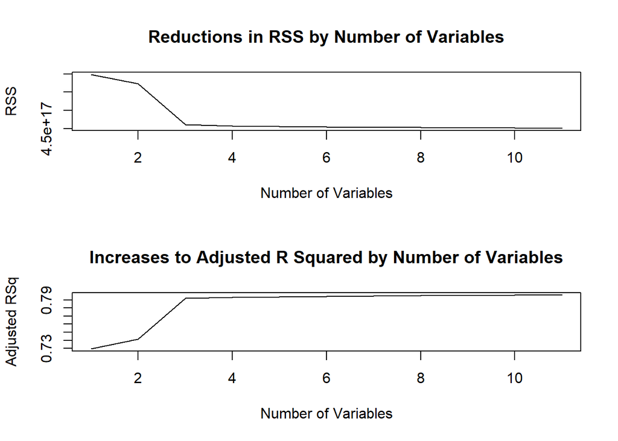

```r
par(mfrow=c(2,1))
plot(reg.summary$rss,xlab="Number of Variables",ylab="RSS",main="Reductions in RSS by Number of Variables",type="l")
plot(reg.summary$adjr2,xlab="Number of Variables",ylab="Adjusted RSq",main="Increases to Adjusted R Squared by Number of Variables",type="l")
```

```r
par(mfrow=c(1,1))
```

## Reviewing the plots, it seems that we probably only need about 3 variables to account for most of the prediction value.

## We now identify the number of explanatory variables required to maximize adjusted R2.

```r
par(mfrow=c(1,1))
plot(reg.summary$adjr2,xlab="Number of Variables",ylab="Adjusted RSq",main="Number of Explanatory Variables Required to Maximize Adjusted R2",type="l")
which.max(reg.summary$adjr2)
```

```
## [1] 11
```

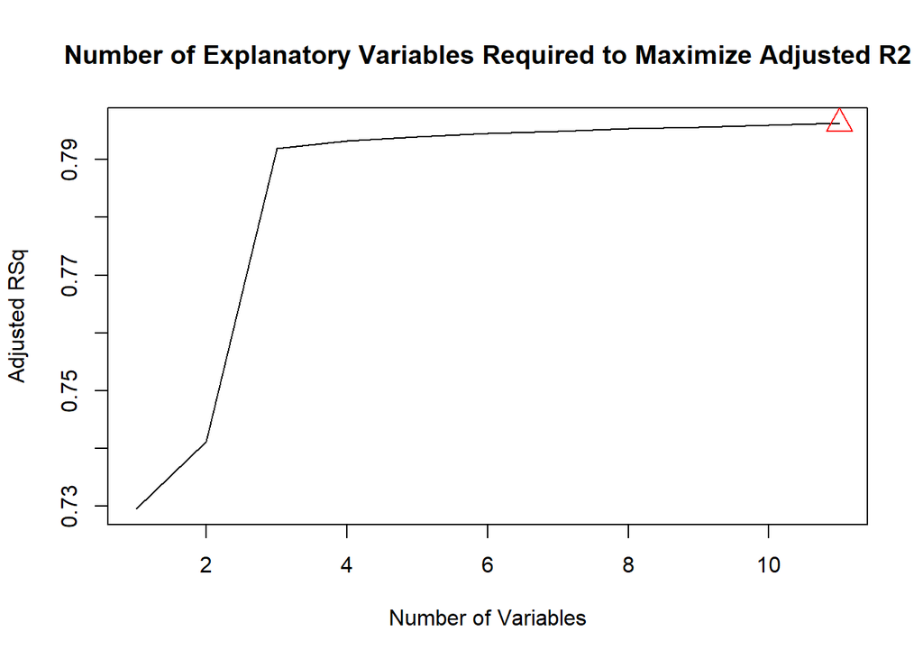

```r
points(11,reg.summary$adjr2[11], col="red",cex=2,pch=2)
```

## The model with the largest adjusted R2 utilizes 11 independent variables.

## Next, identify the model with the number of variables that minimizes AIC.

```r
plot(reg.summary$cp,xlab="Number of Variables",ylab="Cp",main="Number of Variables that Minimizes AIC",type='l')
which.min(reg.summary$cp)
```

```
## [1] 11
```

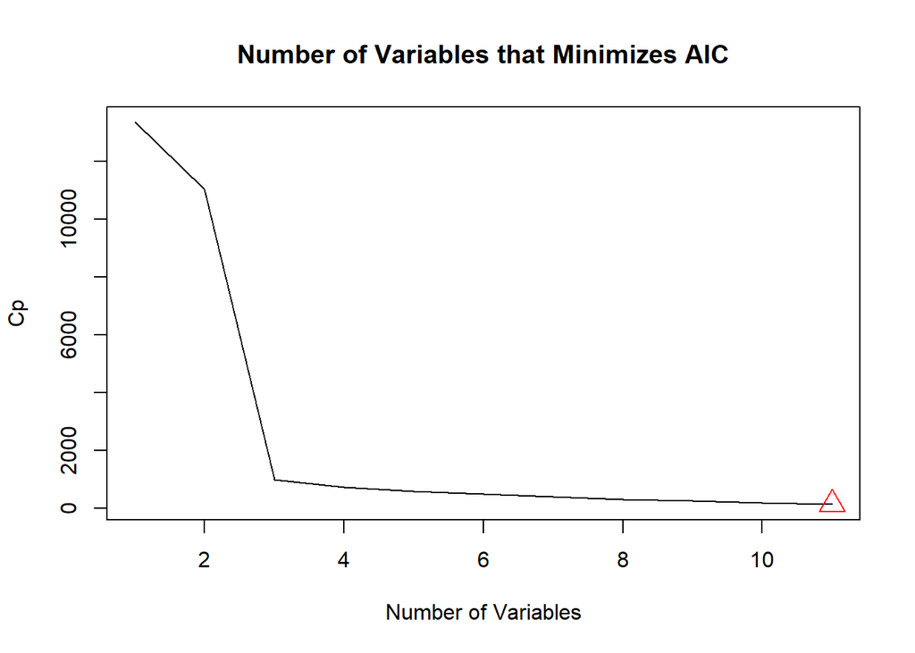

```r
points(11,reg.summary$cp[11],col="red",cex=2,pch=2)
```

## And now BIC.

```r
which.min(reg.summary$bic)
```

```
## [1] 11
```

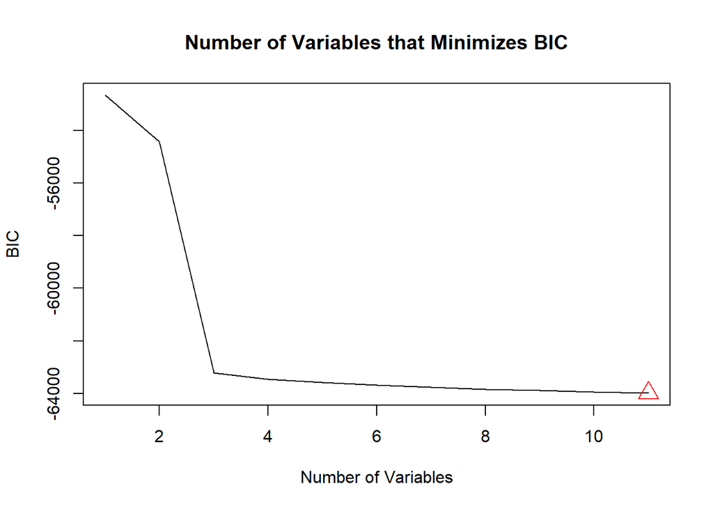

```r
plot(reg.summary$bic,xlab="Number of Variables",ylab="BIC",main="Number of Variables that Minimizes BIC",type='l')
points(11,reg.summary$bic[11],col="red",cex=2,pch=2)
```

## The model with 11 independent variables minimizes AIC and BIC.

## Next we confirm the coefficients for each of the best models according to their respective measurements.

## Maximum R2

```r
coef(regfit.full.yt,11)
```

```
##                (Intercept)                      likes
##               1.246608e+05               3.558478e+01
##                   dislikes              comment_count
##               8.300073e+01              -9.739561e+01
##         genreEntertainment         genreHowto & Style
##               3.924200e+05              -1.153482e+05
## genreNonprofits & Activism                 genreShows
##              -3.240799e+06               2.220547e+05
##     trending_weekdayMonday   trending_weekdayThursday
##               4.316227e+04               1.621731e+04
##              genreThriller              genreTrailers
##               0.000000e+00               0.000000e+00
```

## Maximum Adjusted R2

```r
coef(regfit.full.yt,11)
```

```
##                (Intercept)                      likes
##               1.246608e+05               3.558478e+01
##                   dislikes              comment_count
##               8.300073e+01              -9.739561e+01
##         genreEntertainment         genreHowto & Style
##               3.924200e+05              -1.153482e+05
## genreNonprofits & Activism                 genreShows
##              -3.240799e+06               2.220547e+05
##     trending_weekdayMonday   trending_weekdayThursday
##               4.316227e+04               1.621731e+04
##              genreThriller              genreTrailers
##               0.000000e+00               0.000000e+00
```

## Minimum AIC

```r
coef(regfit.full.yt,11)
```

```
##                (Intercept)                      likes
##               1.246608e+05               3.558478e+01
##                   dislikes              comment_count
##               8.300073e+01              -9.739561e+01
##         genreEntertainment         genreHowto & Style
##               3.924200e+05              -1.153482e+05
## genreNonprofits & Activism                 genreShows
##              -3.240799e+06               2.220547e+05
##     trending_weekdayMonday   trending_weekdayThursday
##               4.316227e+04               1.621731e+04
##              genreThriller              genreTrailers
##               0.000000e+00               0.000000e+00
```

## Minimum BIC

```r
coef(regfit.full.yt,11)
```

```
##                (Intercept)                      likes
##               1.246608e+05               3.558478e+01
##                   dislikes              comment_count
##               8.300073e+01              -9.739561e+01
##         genreEntertainment         genreHowto & Style
##               3.924200e+05              -1.153482e+05
## genreNonprofits & Activism                 genreShows
##              -3.240799e+06               2.220547e+05
##     trending_weekdayMonday   trending_weekdayThursday
##               4.316227e+04               1.621731e+04
##              genreThriller              genreTrailers
##               0.000000e+00               0.000000e+00
```

## We next use stepwise selection to identify models which may help to avoid overfitting.

## The larger the search space, the higher the chance of finding models that look good on the training data, even though they might not have any predictive power on future data.

## Thus an enormous search space can lead to overfitting and high variance of the coefficient estimates. We seek to avoid this potential overfitting.

## We start with Forward Stepwise Selection.

## With Forward Stepwise Selectin, we start at 0 and then add variables individually based on the biggest R squared.

```r
regfit.fwd.yt=regsubsets(views~.,data=us.data.1,nvmax=10,method="forward")
```

```
## Reordering variables and trying again:
```

```r
summary(regfit.fwd.yt)
```

```
## Subset selection object
## Call: regsubsets.formula(views ~ ., data = us.data.1, nvmax = 10, method = "forward")
## 49 Variables  (and intercept)
##                               Forced in Forced out
## likes                             FALSE      FALSE
## dislikes                          FALSE      FALSE
## comment_count                     FALSE      FALSE
## genreAutos & Vehicles             FALSE      FALSE
## genreComedy                       FALSE      FALSE
## genreEducation                    FALSE      FALSE
## genreEntertainment                FALSE      FALSE
## genreFilm & Animation             FALSE      FALSE
## genreGaming                       FALSE      FALSE
## genreHowto & Style                FALSE      FALSE
## genreMusic                        FALSE      FALSE
```

[output cut: 244 more lines]

## The best one-variable model only includes “likes”, the best two-variable model also includes “comment_count”, and the best three-variable model additionally includes “dislikes.”

## Next, we look at Backward Stepwise Selection.

```r
regfit.bwd.yt=regsubsets(views~.,data=us.data.1,nvmax=10,method="backward")
```

```
## Reordering variables and trying again:
```

```r
summary(regfit.bwd.yt)
```

```
## Subset selection object
## Call: regsubsets.formula(views ~ ., data = us.data.1, nvmax = 10, method = "backward")
## 49 Variables  (and intercept)
##                               Forced in Forced out
## likes                             FALSE      FALSE
## dislikes                          FALSE      FALSE
## comment_count                     FALSE      FALSE
## genreAutos & Vehicles             FALSE      FALSE
## genreComedy                       FALSE      FALSE
## genreEducation                    FALSE      FALSE
## genreEntertainment                FALSE      FALSE
## genreFilm & Animation             FALSE      FALSE
## genreGaming                       FALSE      FALSE
## genreHowto & Style                FALSE      FALSE
## genreMusic                        FALSE      FALSE
```

[output cut: 244 more lines]

## All of the 11 variables are the same using the different approaches.

```r
coef(regfit.full.yt,11)
```

```
##                (Intercept)                      likes
##               1.246608e+05               3.558478e+01
##                   dislikes              comment_count
##               8.300073e+01              -9.739561e+01
##         genreEntertainment         genreHowto & Style
##               3.924200e+05              -1.153482e+05
## genreNonprofits & Activism                 genreShows
##              -3.240799e+06               2.220547e+05
##     trending_weekdayMonday   trending_weekdayThursday
##               4.316227e+04               1.621731e+04
##              genreThriller              genreTrailers
##               0.000000e+00               0.000000e+00
```

```r
coef(regfit.fwd.yt,11)
```

```
##                (Intercept)                      likes
##               1.246608e+05               3.558478e+01
##                   dislikes              comment_count
##               8.300073e+01              -9.739561e+01
##         genreEntertainment         genreHowto & Style
##               3.924200e+05              -1.153482e+05
## genreNonprofits & Activism                 genreShows
##              -3.240799e+06               2.220547e+05
##     trending_weekdayMonday   trending_weekdayThursday
##               4.316227e+04               1.621731e+04
##              genreThriller              genreTrailers
##               0.000000e+00               0.000000e+00
```

```r
coef(regfit.bwd.yt,11)
```

```
##                (Intercept)                      likes
##               1.246608e+05               3.558478e+01
##                   dislikes              comment_count
##               8.300073e+01              -9.739561e+01
##         genreEntertainment         genreHowto & Style
##               3.924200e+05              -1.153482e+05
## genreNonprofits & Activism                 genreShows
##              -3.240799e+06               2.220547e+05
##     trending_weekdayMonday   trending_weekdayThursday
##               4.316227e+04               1.621731e+04
##              genreThriller              genreTrailers
##               0.000000e+00               0.000000e+00
```

## Last, we use a validation set approach, splitting the observations into training and testing, to develop a model.

```r
set.seed(11)
train=sample(c(TRUE,FALSE), nrow(us.data.1),rep=TRUE)
test=(!train)
regfit.best=regsubsets(views~.,data=us.data.1[train,],nvmax=10)
```

```
## Reordering variables and trying again:
```

```r
test.mat=model.matrix(views~.,data=us.data.1[test,])
val.errors=rep(NA,10)
for(i in 1:10){
  coefi=coef(regfit.best,id=i)
  pred=test.mat[,names(coefi)]%*%coefi
  val.errors[i]=mean((us.data.1$views[test]-pred)^2)
}
val.errors
```

```
##  [1] 1.611620e+13 1.576281e+13 1.246671e+13 1.246651e+13 1.249321e+13
##  [6] 1.249302e+13 1.246486e+13 1.246575e+13 1.246573e+13 1.246575e+13
```

```r
which.min(val.errors)
```

```
## [1] 7
```

```r
coef(regfit.best,7)
```

```
##                (Intercept)                      likes
##               7.565402e+04               3.546743e+01
##                   dislikes              comment_count
##               8.447166e+01              -9.019602e+01
##         genreEntertainment genreNonprofits & Activism
##               4.218054e+05              -5.184555e+06
##     trending_weekdayMonday     trending_weekdaySunday
##               2.397449e+04              -4.230561e+04
```

## The best model contains 7 variables.

## We now try to choose among the models of different sizes using cross-validation.

## To make this easier next time, we create a “predict” method following the prior steps. There is no predict method for regsubsets.

```r
predict.regsubsets=function(object,newdata,id,...){
  form=as.formula (object$call [[2]])
  mat=model.matrix (form,newdata )
  coefi=coef(object,id=id)
  xvars=names(coefi)
  mat[,xvars ]%*% coefi
}
```

## First, we create a vector that allocates each observation to one of k = 10 folds, and we create a matrix in which we will store the results.

```r
k=10
set.seed (5)
folds=sample(1:k,nrow(us.data.1),replace=TRUE)
cv.errors=matrix(NA,k,10,dimnames=list(NULL,paste(1:10)))

for(j in 1:k){
  best.fit=regsubsets(views~.,data=us.data.1 [folds !=j,],nvmax =10)
  for(i in 1:10) {
    pred=predict(best.fit,us.data.1[folds ==j,],id=i)
    cv.errors[j,i]=mean((us.data.1$views[folds ==j]-pred)^2)
  }
}
```

```
## Reordering variables and trying again:
```

```
## Reordering variables and trying again:
```

```
## Reordering variables and trying again:
```

```
## Reordering variables and trying again:
```

```
## Reordering variables and trying again:
```

```
## Reordering variables and trying again:
```

```
## Reordering variables and trying again:
```

```
## Reordering variables and trying again:
```

```
## Reordering variables and trying again:
```

```
## Reordering variables and trying again:
```

```r
mean.cv.errors=apply(cv.errors,2,mean)
mean.cv.errors
```

```
##            1            2            3            4            5
## 1.498492e+13 1.476672e+13 1.150697e+13 1.150738e+13 1.150004e+13
##            6            7            8            9           10
## 1.146232e+13 1.146984e+13 1.147003e+13 1.147011e+13 1.147031e+13
```

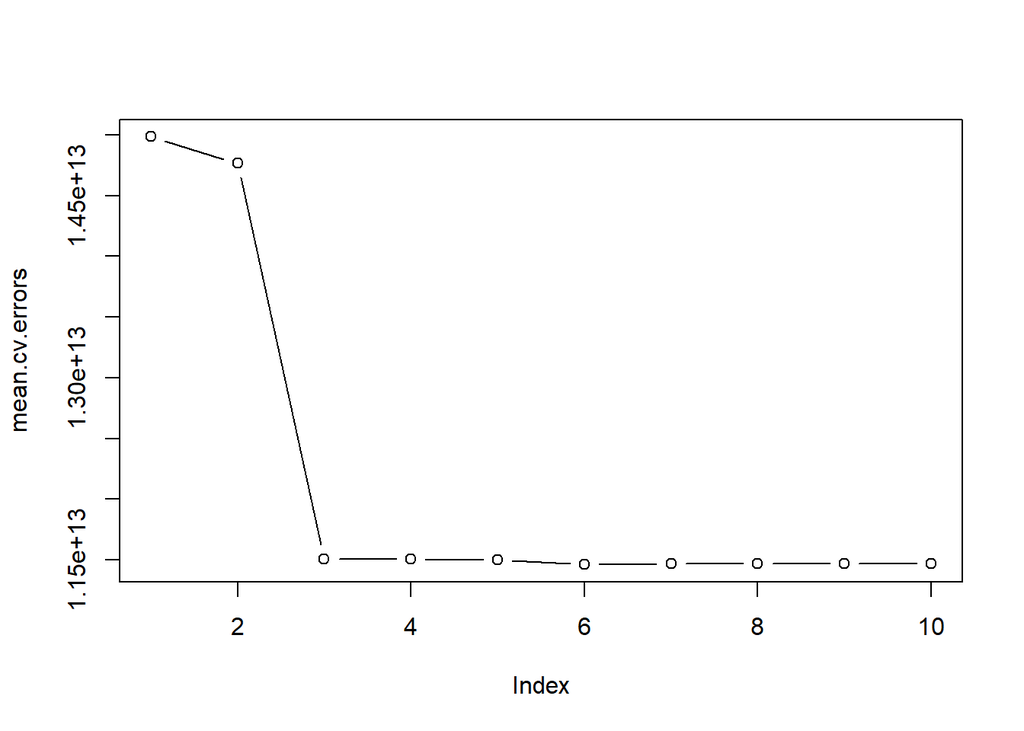

```r
par(mfrow=c(1,1))
plot(mean.cv.errors,type='b')
```

## Reviewing the mean cross-validation error results, the cross-validation approach selects a 6-variable model.

## As the last step, we perform best subset selection on the full data set to confirm the 6-variable model.

```r
reg.best=regsubsets(views~.,data=us.data.1,nvmax=10)
```

```
## Reordering variables and trying again:
```

```r
coef(reg.best,6)
```

```
##                (Intercept)                      likes
##               1.112291e+05               3.560300e+01
##                   dislikes              comment_count
##               8.304395e+01              -9.748289e+01
##         genreEntertainment genreNonprofits & Activism
##               4.080328e+05              -3.225255e+06
##     trending_weekdayMonday
##               4.046112e+04
```

## Now we try a hypothetical example based on this model with 1,000 likes, 500 dislikes, 30 comments, in the Music genre, trending on a Tuesday.

```r
hypothetical.views=(1.112291e+05)+((3.560300e+01)*1000)+((8.304395e+01)*500)+((-9.748289e+01)*30)
```

## Hypothetical views are 185,430.

# **PART 3B: Excluding the comment_count variable since it’s likely that it gained a negative coefficient due to collinearity.**

```r
str(us.data.2)
```

```
## 'data.frame':    40293 obs. of  10 variables:
##  $ views                  : int  2633079 1080795 5186780 259340 12887949 153898 705015 228745 28013 945670 ...
##  $ likes                  : int  69999 23939 510 9059 338755 7551 37505 1848 2374 21927 ...
##  $ dislikes               : int  2377 950 1774 177 6727 1028 1413 41 15 832 ...
##  $ genre                  : Factor w/ 31 levels "Action/Adventure",..: 11 11 11 11 11 11 11 11 11 11 ...
##  $ trending_weekday       : Factor w/ 7 levels "Friday","Monday",..: 2 2 7 5 1 5 4 2 5 1 ...
##  $ publish_date_weekday   : Factor w/ 7 levels "Friday","Monday",..: 6 6 5 1 6 7 3 6 2 6 ...
##  $ title.sentiment        : num  1 -0.265 0 0.337 0.212 ...
##  $ channel_title.sentiment: num  0 0 0 0 0 0 0 0 0 0 ...
##  $ tags.sentiment         : num  1.942 -0.323 0.2 1.134 0.561 ...
##  $ description.sentiment  : num  0.3117 0.2411 -0.0329 0.2703 0.1687 ...
```

```r
dim(us.data.2)
```

```
## [1] 40293    10
```

## Dimensions are 40293 by 10.

```r
regfit.full.yt1=regsubsets(views~.,us.data.2)
```

```
## Reordering variables and trying again:
```

```r
summary(regfit.full.yt1)
```

```
## Subset selection object
## Call: regsubsets.formula(views ~ ., us.data.2)
## 48 Variables  (and intercept)
##                               Forced in Forced out
## likes                             FALSE      FALSE
## dislikes                          FALSE      FALSE
## genreAutos & Vehicles             FALSE      FALSE
## genreComedy                       FALSE      FALSE
## genreEducation                    FALSE      FALSE
## genreEntertainment                FALSE      FALSE
## genreFilm & Animation             FALSE      FALSE
## genreGaming                       FALSE      FALSE
## genreHowto & Style                FALSE      FALSE
## genreMusic                        FALSE      FALSE
## genreNews & Politics              FALSE      FALSE
## genreNonprofits & Activism        FALSE      FALSE
## genrePeople & Blogs               FALSE      FALSE
## genrePets & Animals               FALSE      FALSE
## genreScience & Technology         FALSE      FALSE
## genreShows                        FALSE      FALSE
## genreSports                       FALSE      FALSE
## trending_weekdayMonday            FALSE      FALSE
## trending_weekdaySaturday          FALSE      FALSE
## trending_weekdaySunday            FALSE      FALSE
## trending_weekdayThursday          FALSE      FALSE
## trending_weekdayTuesday           FALSE      FALSE
## trending_weekdayWednesday         FALSE      FALSE
## publish_date_weekdayMonday        FALSE      FALSE
## publish_date_weekdaySaturday      FALSE      FALSE
## publish_date_weekdaySunday        FALSE      FALSE
## publish_date_weekdayThursday      FALSE      FALSE
## publish_date_weekdayTuesday       FALSE      FALSE
## publish_date_weekdayWednesday     FALSE      FALSE
## title.sentiment                   FALSE      FALSE
## channel_title.sentiment           FALSE      FALSE
## tags.sentiment                    FALSE      FALSE
## description.sentiment             FALSE      FALSE
## genreAnime/Animation              FALSE      FALSE
## genreClassics                     FALSE      FALSE
## genreDocumentary                  FALSE      FALSE
```

[output cut: 169 more lines]

```
## 5  ( 1 ) " "                           " "
## 6  ( 1 ) " "                           " "
## 7  ( 1 ) " "                           " "
## 8  ( 1 ) " "                           " "
## 9  ( 1 ) " "                           "*"
##          channel_title.sentiment tags.sentiment description.sentiment
## 1  ( 1 ) " "                     " "            " "
## 2  ( 1 ) " "                     " "            " "
## 3  ( 1 ) " "                     " "            " "
## 4  ( 1 ) " "                     " "            " "
## 5  ( 1 ) " "                     " "            " "
## 6  ( 1 ) " "                     " "            " "
## 7  ( 1 ) " "                     " "            " "
## 8  ( 1 ) "*"                     " "            " "
## 9  ( 1 ) "*"                     " "            " "
```

```r
regfit.full.yt1=regsubsets(views~.,data=us.data.2,nvmax=9)
```

```
## Reordering variables and trying again:
```

```r
summary(regfit.full.yt1)
```

```
## Subset selection object
## Call: regsubsets.formula(views ~ ., data = us.data.2, nvmax = 9)
## 48 Variables  (and intercept)
##                               Forced in Forced out
## likes                             FALSE      FALSE
## dislikes                          FALSE      FALSE
## genreAutos & Vehicles             FALSE      FALSE
## genreComedy                       FALSE      FALSE
## genreEducation                    FALSE      FALSE
## genreEntertainment                FALSE      FALSE
## genreFilm & Animation             FALSE      FALSE
## genreGaming                       FALSE      FALSE
## genreHowto & Style                FALSE      FALSE
## genreMusic                        FALSE      FALSE
## genreNews & Politics              FALSE      FALSE
```

[output cut: 226 more lines]

```r
reg.summary1=summary(regfit.full.yt1)
names(reg.summary1)
```

```
## [1] "which"  "rsq"    "rss"    "adjr2"  "cp"     "bic"    "outmat" "obj"
```

## We check the cumulative progression of R2 values against the variables.

```r
reg.summary1$rsq
```

```
##  [1] 0.7295423 0.7402840 0.7412009 0.7420867 0.7425696 0.7429796 0.7432905
##  [8] 0.7436069 0.7438797 0.7441412
```

## The results show that R^2 increases from 0.7295 to 0.7441 when we include all variables.

## Next we look at how well the number of variables explains RSS and Adjusted R2 scores.

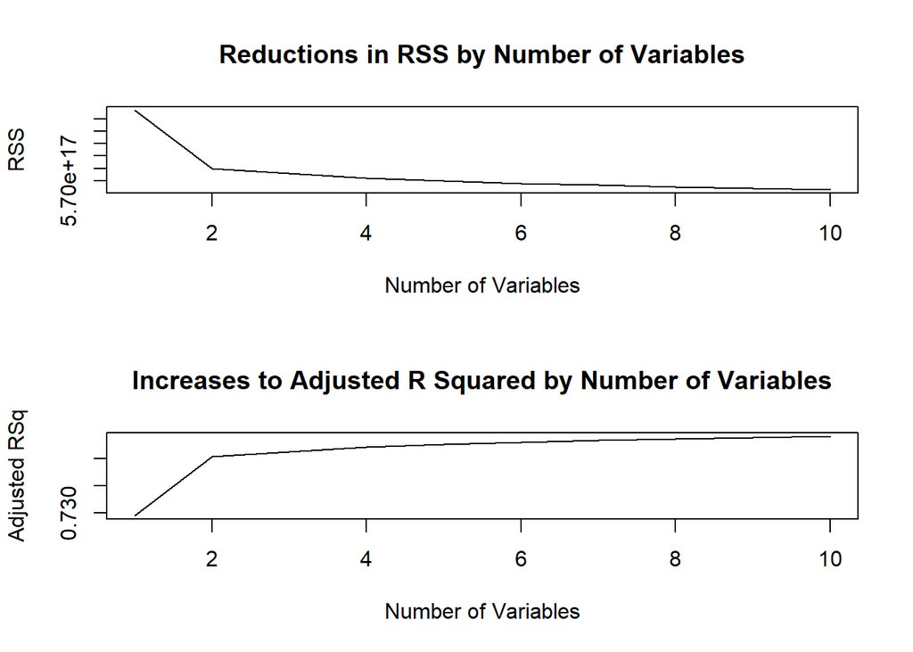

```r
par(mfrow=c(2,1))
plot(reg.summary1$rss,xlab="Number of Variables",ylab="RSS",main="Reductions in RSS by Number of Variables",type="l")
plot(reg.summary1$adjr2,xlab="Number of Variables",ylab="Adjusted RSq",main="Increases to Adjusted R Squared by Number of Variables",type="l")
```

```r
par(mfrow=c(1,1))
```

## We now identify the number of explanatory variables required to maximize adjusted R2.

```r
par(mfrow=c(1,1))
plot(reg.summary1$adjr2,xlab="Number of Variables",ylab="Adjusted RSq",main="Number of Explanatory Variables Required to Maximize Adjusted R2",type="l")
which.max(reg.summary1$adjr2)
```

```
## [1] 10
```

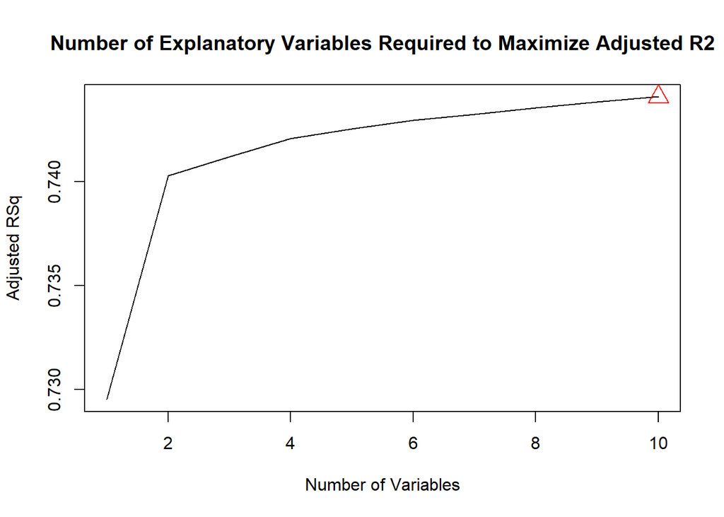

```r
points(10,reg.summary1$adjr2[10], col="red",cex=2,pch=2)
```

## The model with the largest adjusted R2 utilizes 10 independent variables.

## Next, we identify the model with the number of variables that minimizes AIC. Note that Cp is AIC.

```r
plot(reg.summary1$cp,xlab="Number of Variables",ylab="Cp",main="Number of Variables that Minimizes AIC",type='l')
which.min(reg.summary1$cp)
```

```
## [1] 10
```

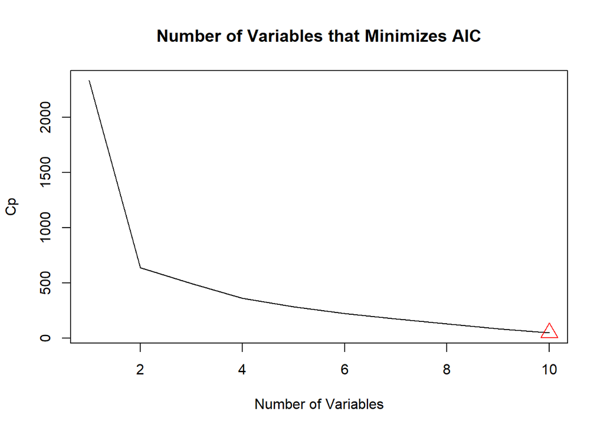

```r
points(10,reg.summary1$cp[10],col="red",cex=2,pch=2)
```

## And now BIC.

```r
which.min(reg.summary1$bic)
```

```
## [1] 10
```

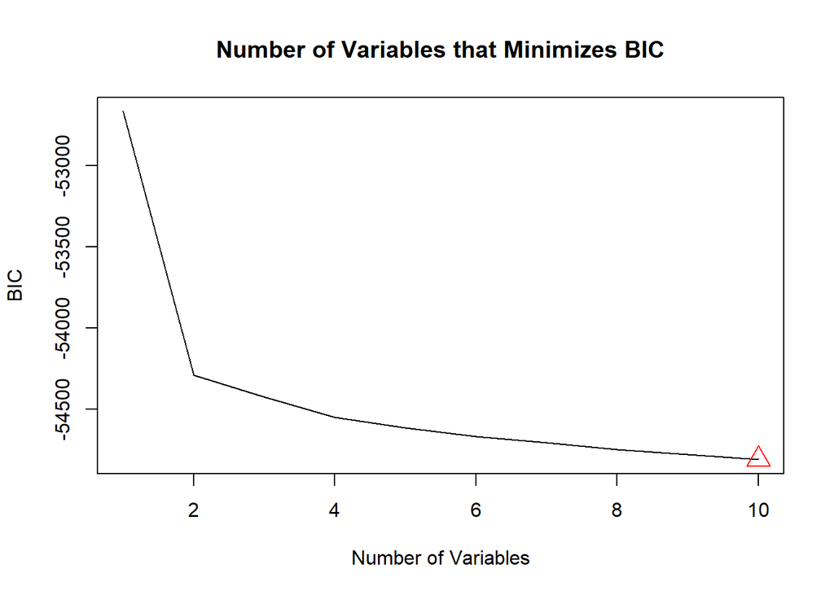

```r
plot(reg.summary1$bic,xlab="Number of Variables",ylab="BIC",main="Number of Variables that Minimizes BIC",type='l')
points(10,reg.summary1$bic[10],col="red",cex=2,pch=2)
```

## Again, even withough the comment_count variable, the model with 10 independent variables minimizes AIC and BIC.

## Next we confirm the coefficients for each of the best models according to their respective measurements.

## Maximum R2

```r
coef(regfit.full.yt1,10)
```

```
##                (Intercept)                      likes
##               3.001120e+05               2.579793e+01
##                   dislikes         genreEntertainment
##               2.973625e+01               2.549486e+05
##         genreHowto & Style genreNonprofits & Activism
##              -3.652998e+05              -6.173997e+06
##                 genreShows     trending_weekdaySunday
##               1.084551e+05              -4.472987e+04
##   trending_weekdayThursday              genreThriller
##               2.352725e+02               0.000000e+00
##              genreTrailers
##               0.000000e+00
```

## Maximum Adjusted R2

```r
coef(regfit.full.yt1,10)
```

```
##                (Intercept)                      likes
##               3.001120e+05               2.579793e+01
##                   dislikes         genreEntertainment
##               2.973625e+01               2.549486e+05
##         genreHowto & Style genreNonprofits & Activism
##              -3.652998e+05              -6.173997e+06
##                 genreShows     trending_weekdaySunday
##               1.084551e+05              -4.472987e+04
##   trending_weekdayThursday              genreThriller
##               2.352725e+02               0.000000e+00
##              genreTrailers
##               0.000000e+00
```

## Minimum AIC

```r
coef(regfit.full.yt1,10)
```

```
##                (Intercept)                      likes
##               3.001120e+05               2.579793e+01
##                   dislikes         genreEntertainment
##               2.973625e+01               2.549486e+05
##         genreHowto & Style genreNonprofits & Activism
##              -3.652998e+05              -6.173997e+06
##                 genreShows     trending_weekdaySunday
##               1.084551e+05              -4.472987e+04
##   trending_weekdayThursday              genreThriller
##               2.352725e+02               0.000000e+00
##              genreTrailers
##               0.000000e+00
```

## Minimum BIC

```r
coef(regfit.full.yt1,10)
```

```
##                (Intercept)                      likes
##               3.001120e+05               2.579793e+01
##                   dislikes         genreEntertainment
##               2.973625e+01               2.549486e+05
##         genreHowto & Style genreNonprofits & Activism
##              -3.652998e+05              -6.173997e+06
##                 genreShows     trending_weekdaySunday
##               1.084551e+05              -4.472987e+04
##   trending_weekdayThursday              genreThriller
##               2.352725e+02               0.000000e+00
##              genreTrailers
##               0.000000e+00
```

## We once again use stepwise selection to identify models which may help to avoid overfitting.

## We start with Forward Stepwise Selection.

```r
regfit.fwd.yt1=regsubsets(views~.,data=us.data.2,nvmax=9,method="forward")
```

```
## Reordering variables and trying again:
```

```r
summary(regfit.fwd.yt1)
```

```
## Subset selection object
## Call: regsubsets.formula(views ~ ., data = us.data.2, nvmax = 9, method = "forward")
## 48 Variables  (and intercept)
##                               Forced in Forced out
## likes                             FALSE      FALSE
## dislikes                          FALSE      FALSE
## genreAutos & Vehicles             FALSE      FALSE
## genreComedy                       FALSE      FALSE
## genreEducation                    FALSE      FALSE
## genreEntertainment                FALSE      FALSE
## genreFilm & Animation             FALSE      FALSE
## genreGaming                       FALSE      FALSE
## genreHowto & Style                FALSE      FALSE
## genreMusic                        FALSE      FALSE
## genreNews & Politics              FALSE      FALSE
```

[output cut: 226 more lines]

## The best one-variable model only includes “likes”, the best two-variable model also includes dislikes, and the best three-variable model additionally includes the Nonprofits & Activism genre.

## Next, we look at Backward Stepwise Selection.

```r
regfit.bwd.yt1=regsubsets(views~.,data=us.data.2,nvmax=9,method="backward")
```

```
## Reordering variables and trying again:
```

```r
summary(regfit.bwd.yt1)
```

```
## Subset selection object
## Call: regsubsets.formula(views ~ ., data = us.data.2, nvmax = 9, method = "backward")
## 48 Variables  (and intercept)
##                               Forced in Forced out
## likes                             FALSE      FALSE
## dislikes                          FALSE      FALSE
## genreAutos & Vehicles             FALSE      FALSE
## genreComedy                       FALSE      FALSE
## genreEducation                    FALSE      FALSE
## genreEntertainment                FALSE      FALSE
## genreFilm & Animation             FALSE      FALSE
## genreGaming                       FALSE      FALSE
## genreHowto & Style                FALSE      FALSE
## genreMusic                        FALSE      FALSE
## genreNews & Politics              FALSE      FALSE
```

[output cut: 226 more lines]

```r
coef(regfit.full.yt1,10)
```

```
##                (Intercept)                      likes
##               3.001120e+05               2.579793e+01
##                   dislikes         genreEntertainment
##               2.973625e+01               2.549486e+05
##         genreHowto & Style genreNonprofits & Activism
##              -3.652998e+05              -6.173997e+06
##                 genreShows     trending_weekdaySunday
##               1.084551e+05              -4.472987e+04
##   trending_weekdayThursday              genreThriller
##               2.352725e+02               0.000000e+00
##              genreTrailers
##               0.000000e+00
```

```r
coef(regfit.fwd.yt1,10)
```

```
##                 (Intercept)                       likes
##                3.185428e+05                2.579144e+01
##                    dislikes                  genreMusic
##                2.993302e+01               -6.985877e+03
##  genreNonprofits & Activism      trending_weekdayMonday
##               -6.210376e+06                4.241624e+04
##      trending_weekdaySunday  publish_date_weekdayMonday
##               -3.787079e+04                7.025054e+04
## publish_date_weekdayTuesday               genreThriller
##               -6.352919e+04                0.000000e+00
##               genreTrailers
##                0.000000e+00
```

```r
coef(regfit.bwd.yt1,10)
```

```
##                (Intercept)                      likes
##               3.001120e+05               2.579793e+01
##                   dislikes         genreEntertainment
##               2.973625e+01               2.549486e+05
##         genreHowto & Style genreNonprofits & Activism
##              -3.652998e+05              -6.173997e+06
##                 genreShows     trending_weekdaySunday
##               1.084551e+05              -4.472987e+04
##   trending_weekdayThursday              genreThriller
##               2.352725e+02               0.000000e+00
##              genreTrailers
##               0.000000e+00
```

## Last, we use a validation set approach, splitting the observations into training and testing, to develop a model.

```r
set.seed(11)
train=sample(c(TRUE,FALSE), nrow(us.data.2),rep=TRUE)
test=(!train)
regfit.best1=regsubsets(views~.,data=us.data.2[train,],nvmax=9)
```

```
## Reordering variables and trying again:
```

```r
test.mat=model.matrix(views~.,data=us.data.2[test,])
val.errors=rep(NA,9)
for(i in 1:9){
  coefi=coef(regfit.best1,id=i)
  pred=test.mat[,names(coefi)]%*%coefi
  val.errors[i]=mean((us.data.2$views[test]-pred)^2)
}
val.errors
```

```
## [1] 1.611620e+13 1.535780e+13 1.535767e+13 1.535708e+13 1.536237e+13
## [6] 1.536175e+13 1.536175e+13 1.536175e+13 1.533649e+13
```

```r
which.min(val.errors)
```

```
## [1] 9
```

```r
coef(regfit.best1,9)
```

```
##                 (Intercept)                       likes
##                3.801743e+05                2.624002e+01
##                    dislikes                 genreComedy
##                3.067234e+01               -5.807564e+05
##                  genreMusic  genreNonprofits & Activism
##               -1.863107e+05               -8.218971e+06
##      trending_weekdaySunday publish_date_weekdayTuesday
##               -4.657506e+04               -2.455801e+04
##               genreThriller               genreTrailers
##                0.000000e+00                0.000000e+00
```

## The best model contains 9 variables.

## We now try to choose among the models of different sizes using cross-validation.

## To make this easier next time, we create a “predict” method following the prior steps. There is no predict method for regsubsets.

```r
predict.regsubsets1=function(object,newdata,id,...){
  form=as.formula (object$call [[2]])
  mat=model.matrix (form,newdata )
  coefi=coef(object,id=id)
  xvars=names(coefi)
  mat[,xvars ]%*% coefi
}
```

## We next create a vector that allocates each observation to one of k = 10 folds, and we create a matrix in which we will store the results.

```r
k=10
set.seed (5)
folds1=sample(1:k,nrow(us.data.2),replace=TRUE)
cv.errors1=matrix(NA,k,9,dimnames=list(NULL,paste(1:9)))

for(j in 1:k){
  best.fit1=regsubsets(views~.,data=us.data.2 [folds1!=j,],nvmax =9)
  for(i in 1:9) {
    pred=predict(best.fit1,us.data.2[folds1==j,],id=i)
    cv.errors1[j,i]=mean((us.data.2$views[folds ==j]-pred)^2)
  }
}
```

```
## Reordering variables and trying again:
```

```
## Reordering variables and trying again:
```

```
## Reordering variables and trying again:
```

```
## Reordering variables and trying again:
```

```
## Reordering variables and trying again:
```

```
## Reordering variables and trying again:
```

```
## Reordering variables and trying again:
```

```
## Reordering variables and trying again:
```

```
## Reordering variables and trying again:
```

```
## Reordering variables and trying again:
```

```r
mean.cv.errors.1=apply(cv.errors1,2,mean)
mean.cv.errors.1
```

```
##            1            2            3            4            5
## 1.498492e+13 1.443661e+13 1.437782e+13 1.440273e+13 1.440696e+13
##            6            7            8            9
## 1.440693e+13 1.439237e+13 1.439237e+13 1.438641e+13
```

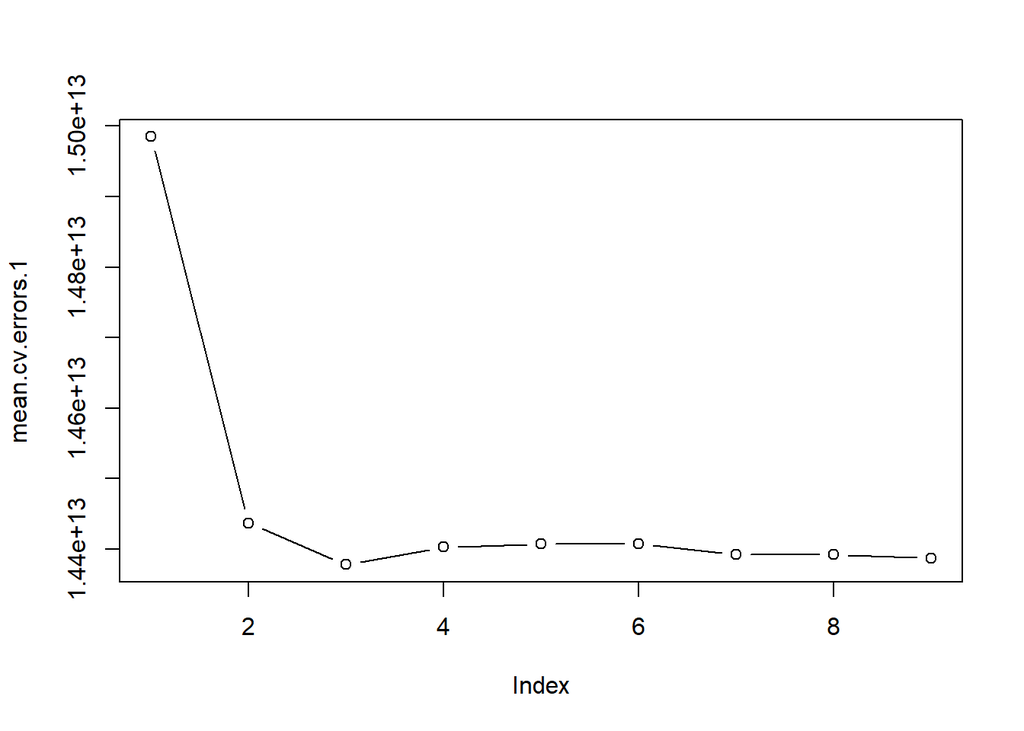

```r
par(mfrow=c(1,1))
plot(mean.cv.errors.1,type='b')
```

## Reviewing the mean cross-validation error results, the cross-validation approach selects a 3-variable model.

## As the last step, we perform best subset selection on the full data set to confirm the 3-variable model.

```r
reg.best1=regsubsets(views~.,data=us.data.2,nvmax=9)
```

```
## Reordering variables and trying again:
```

```r
coef(reg.best1,3)
```

```
##            (Intercept)                  likes               dislikes
##           319092.17332               25.78769               29.36622
## trending_weekdaySunday
##           -48254.61414
```

## Now we try the same hypothetical example as before based again on a model with 1,000 likes, 500 dislikes, 30 comments, in the Music genre, trending on a Tuesday.

```r
hypothetical.views.3b=(319092.17332)+((25.78769)*1000)+((29.36622)*500)
```